# Statistical analyses

```r
# Load packages
library(ggplot2)
library(dplyr)
library(lme4)
library(lmerTest)
options(na.action = na.omit)
```

## Load data

```r
load("/home/amira.azizan/Documents/Y320/GenDivDatabase/GDfelids/Data/Popgenden.rda")
```

- ref.gen format: FirstAuthor_FirstPublicationTitle_YearofPublication
- ref.den format: FirstAuthor_JournalName_YearofPublication
- average: AVE - only averaged GD available in the study, LOCUS - GD per locus is available and averaging the GD was done by Amira

### 1. log10 transformed variables

```r
gen_clus$n.allele_log <- log10(gen_clus$n.allele)
gen_clus$sample.size_log <- log10(gen_clus$sample.size)
gen_clus$DP_log <- log10(gen_clus$DP_mean)
gen_clus$BS_log <- log10(gen_clus$BS)

gen_count$n.allele_log <- log10(gen_count$n.allele)
gen_count$sample.size_log <- log10(gen_count$sample.size)
gen_count$DP_log <- log10(gen_count$DP)
gen_count$BS_log <- log10(gen_count$BS)
```

### 2. Plot the distribution of each variable

#### a) Cluster data set

##### DP

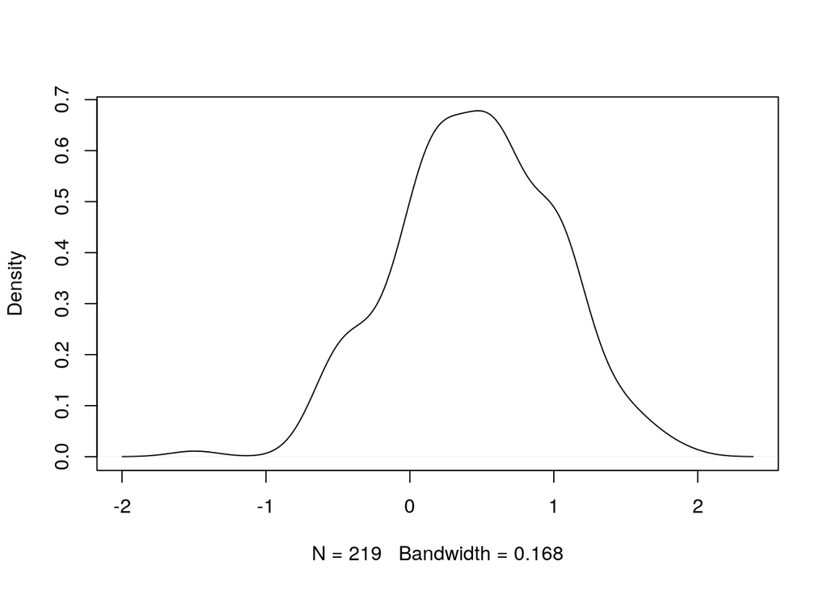

##### Ho

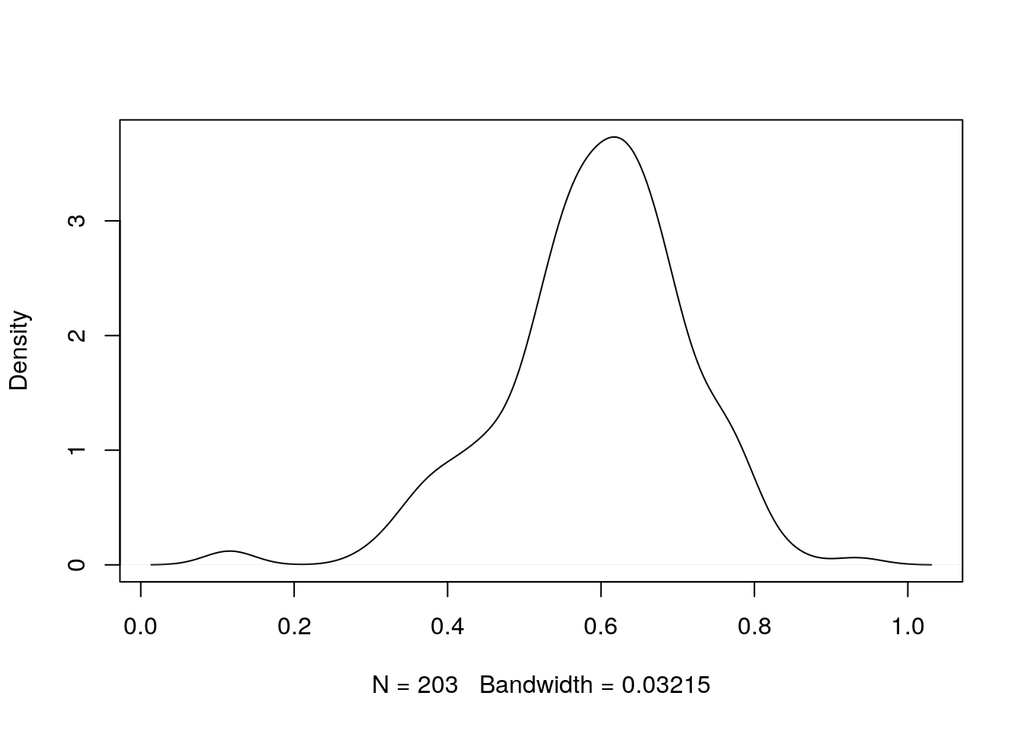

##### He

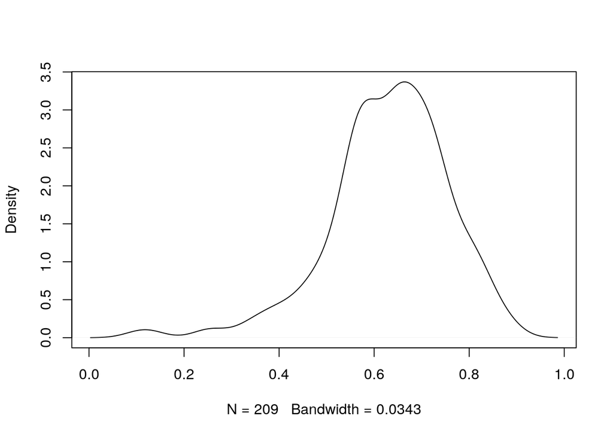

##### Allelic richness

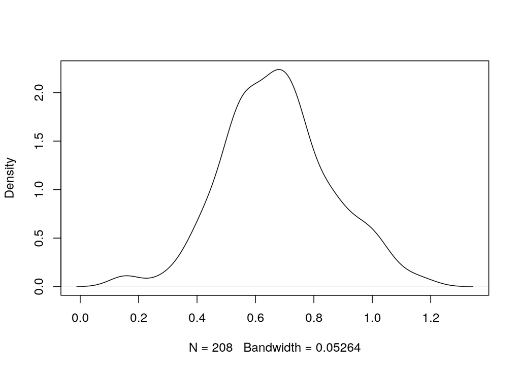

#### b) Country data set

##### DP

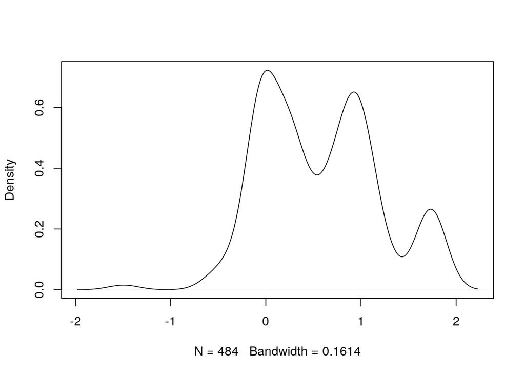

##### Ho

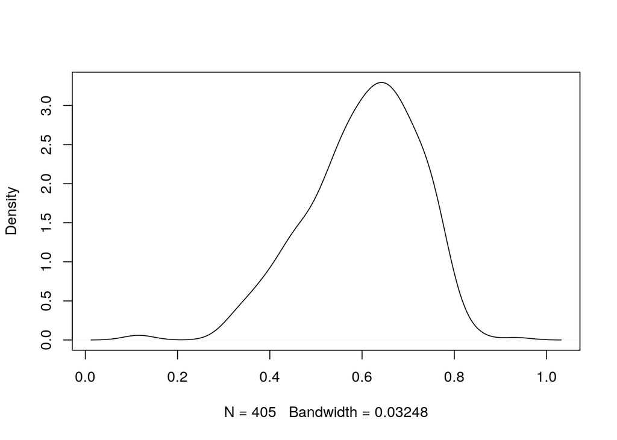

##### He

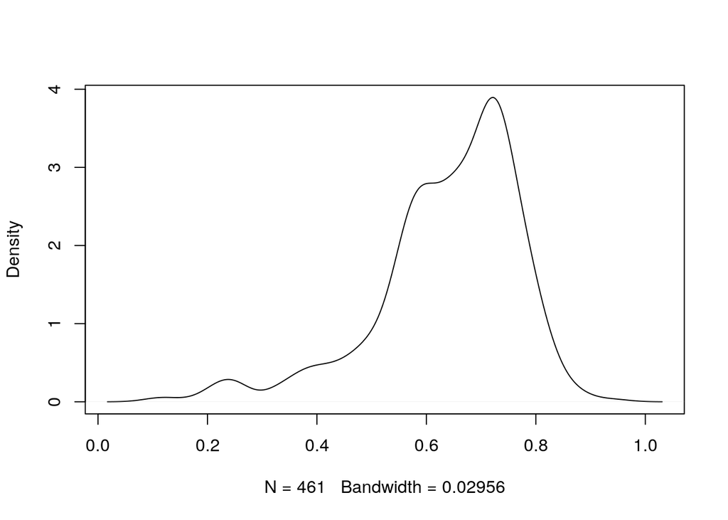

##### Allelic richness

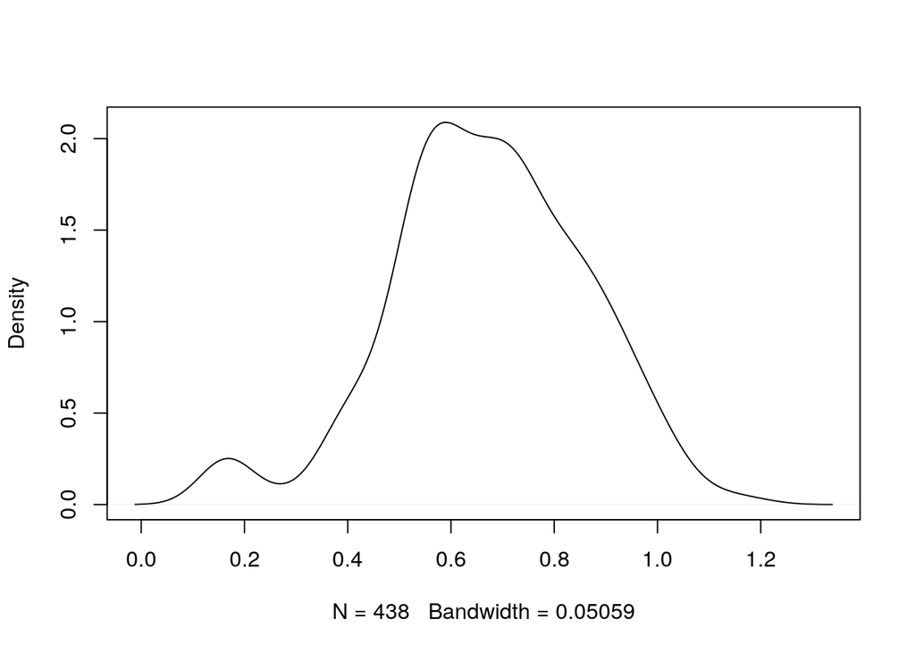

### 3. Simple correlation test with sample size

sample size refers to the mean number of individuals sampled for the GD estimates

- $H_o$ No correlation between GD and sample size size
- $H_1$ GD increases with sample size

```r
# Pearson correlation coefficient
c1 <- cor.test(gen_clus$ho, log10(gen_clus$sample.size), method = "pearson", alt="g")[c("p.value","estimate")]
c2 <- cor.test(gen_clus$he, log10(gen_clus$sample.size), method = "pearson", alt="g")[c("p.value","estimate")]
c3 <- cor.test(gen_clus$n.allele, log10(gen_clus$sample.size), method = "pearson", alt="g")[c("p.value","estimate")]
```

|  | p.value | estimate |
| --- | --- | --- |
| HoxSS | 0.0008925 | 0.2179545 |
| HexSS | 0.0000254 | 0.2764688 |
| ArxSS | 0.0000000 | 0.6365995 |

All 3 GD estimates are correlated to sample size. Allelic richness has significantly high correlation, with r = 0.6365995

###4. Outlier detections Remove outliers in cluster dataset using the boxplot

*boxplots before outliers were removed*

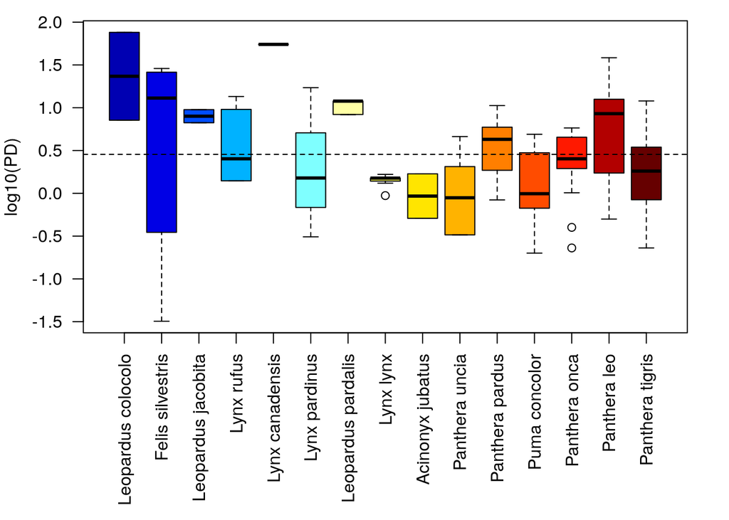

```r
par(mar=c(9,4,1,2))
boxplot(gen_clus$DP_log~gen_clus$sp,   xlab=NA, las=2, col=no_green[names(no_green) %in% unique(gen_clus$sp)], ylab="log10(PD)")
abline(h=mean(gen_clus$DP_log), lty=2)
```

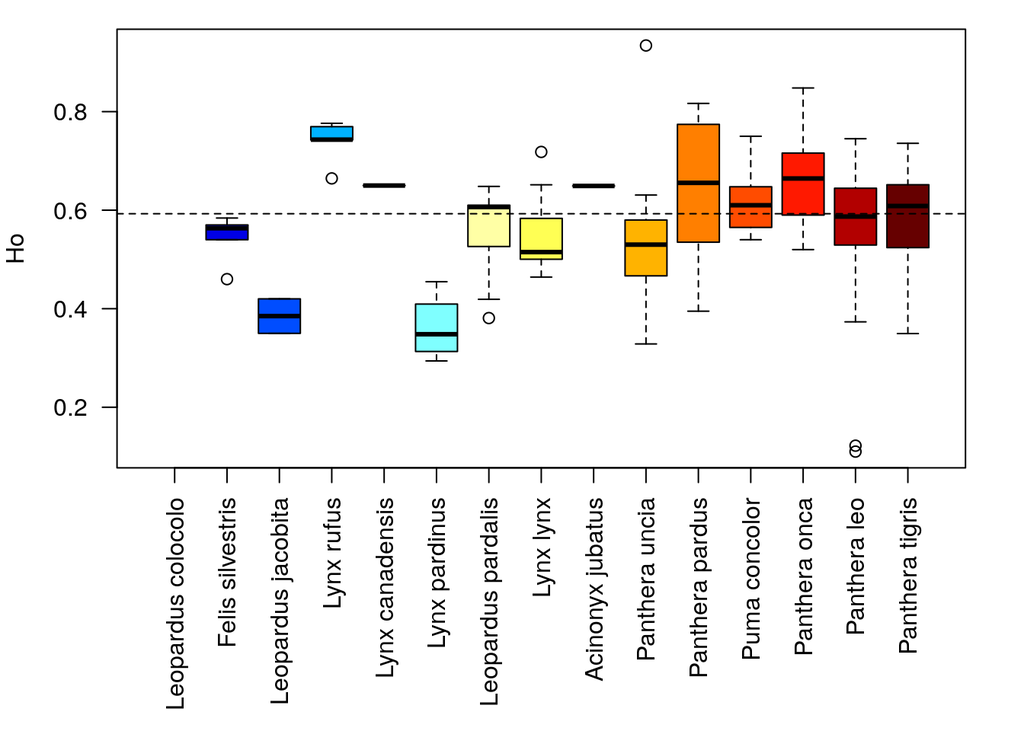

```r
boxplot(gen_clus$ho~gen_clus$sp, col=no_green[names(no_green) %in% unique(gen_clus$sp)] , xlab=NA,  las=2, ylab="Ho")
abline(h=mean(gen_clus$ho, na.rm=T), lty=2)
```

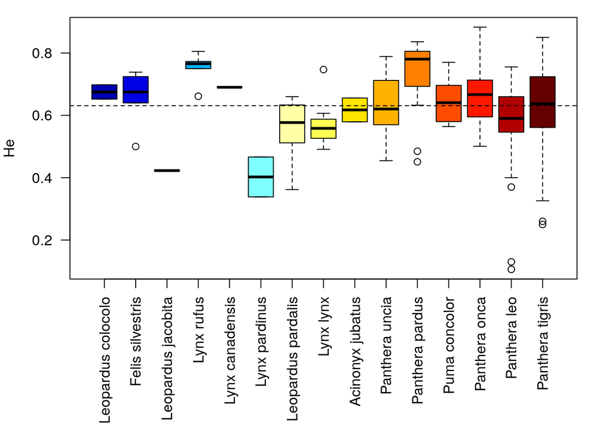

```r
boxplot(gen_clus$he~gen_clus$sp, col=no_green[names(no_green) %in% unique(gen_clus$sp)], las=2, xlab=NA,  ylab="He",)
abline(h=mean(gen_clus$he, na.rm=T), lty=2)
```

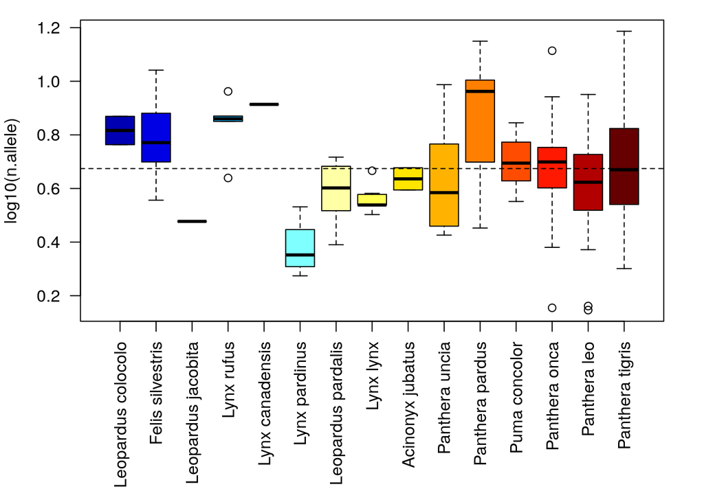

```r
boxplot(log10(gen_clus$n.allele)~gen_clus$sp, col=no_green[names(no_green) %in% unique(gen_clus$sp)], las=2, xlab=NA,cex=1,  ylab="log10(n.allele)")
abline(h=mean(log10(gen_clus$n.allele), na.rm=T), lty=2)
```

```r
Ho <- data.frame(sp=character(), rownames=numeric())

for (j in unique(gen_clus$sp)){
   felsil <- subset(gen_clus, sp %in% j)
   x = felsil$ho
   if (all(is.na(x))) next
   out <- boxplot(x, plot=FALSE)$out
   a1 <- felsil[x %in% out,]
   if (length(out) == 0) next
   a2 <- data.frame(sp=j, rownames=rownames(a1))
   Ho <- rbind(Ho, a2)
}

He <- data.frame(sp=character(), rownames=numeric())

for (j in unique(gen_clus$sp)){
   felsil <- subset(gen_clus, sp %in% j)
   x = felsil$he
   if (all(is.na(x))) next
   Ar_out <- boxplot(x, plot=FALSE)$out
   a1 <- felsil[x %in% Ar_out,]
   if (length(Ar_out) == 0) next
   a2 <- data.frame(sp=j, rownames=rownames(a1))
   He <- rbind(He, a2)
}


Ar <- data.frame(sp=character(), rownames=numeric())

for (j in unique(gen_clus$sp)){
   felsil <- subset(gen_clus, sp %in% j)
   x = log10(felsil$n.allele)
   if (all(is.na(x))) next
   Ar_out <- boxplot(x, plot=FALSE)$out
   a1 <- felsil[x %in% Ar_out,]
   if (length(Ar_out) == 0) next
   a2 <- data.frame(sp=j, rownames=rownames(a1))
   Ar <- rbind(Ar, a2)
}

Dp <- data.frame(sp=character(), rownames=numeric())

for (j in unique(gen_clus$sp)){
   felsil <- subset(gen_clus, sp %in% j)
   x = log10(felsil$DP_mean)
   if (all(is.na(x))) next
   Ar_out <- boxplot(x, plot=FALSE)$out
   a1 <- felsil[x %in% Ar_out,]
   if (length(Ar_out) == 0) next
   a2 <- data.frame(sp=j, rownames=rownames(a1))
   Dp <- rbind(Dp, a2)
}

# tagg outliers
gen_clus$ho_out <- FALSE
gen_clus$ho_out[rownames(gen_clus) %in% Ho$rownames] <- TRUE

gen_clus$he_out <- FALSE
gen_clus$he_out[rownames(gen_clus) %in% He$rownames] <- TRUE

gen_clus$ar_out <- FALSE
gen_clus$ar_out[rownames(gen_clus) %in% Ar$rownames] <- TRUE

gen_clus$dp_out <- FALSE
gen_clus$dp_out[rownames(gen_clus) %in% Dp$rownames] <- TRUE

gen_clus[which(gen_clus$DP_log %in% boxplot(gen_clus$DP_log, plot=F)$out),"dp_out"] <- TRUE
```

*Boxplots after outliers were removed*

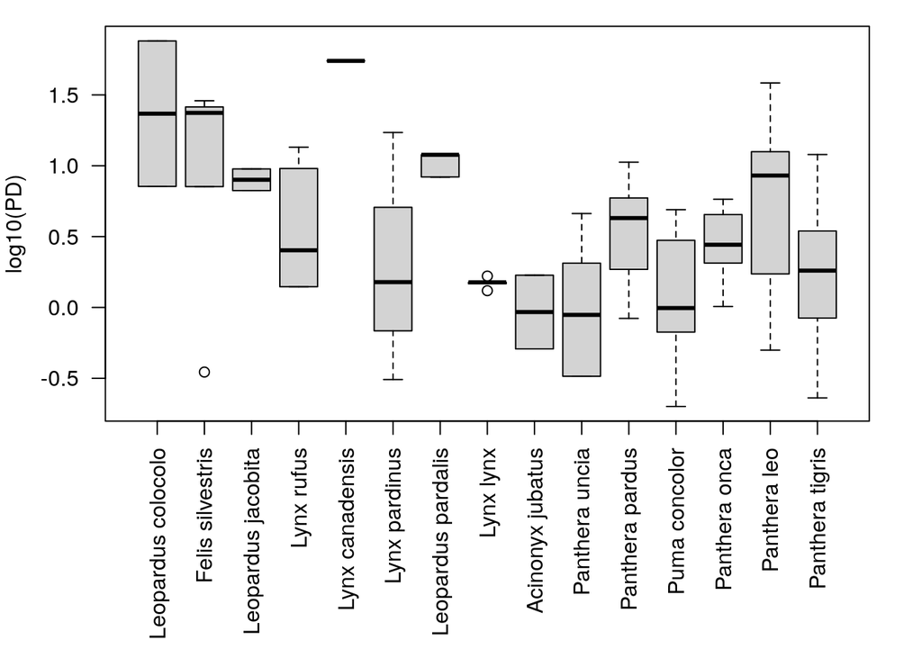

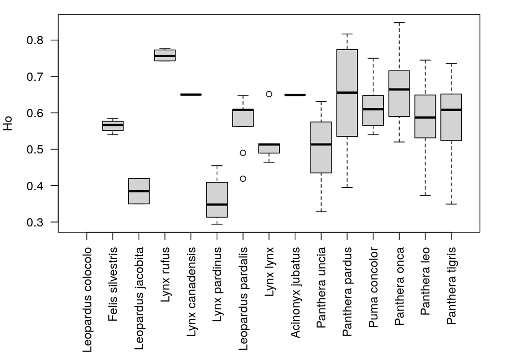

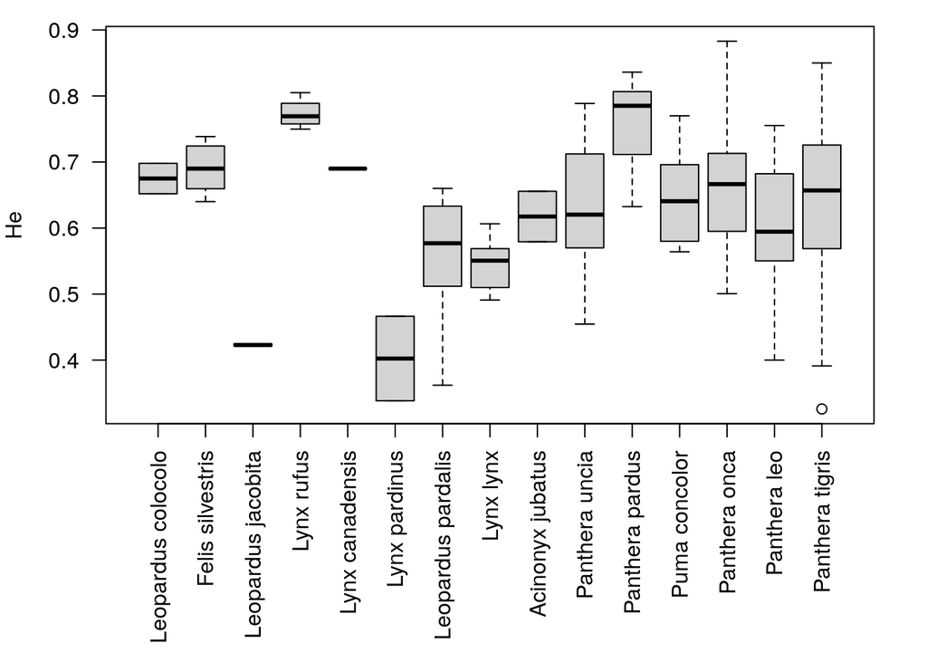

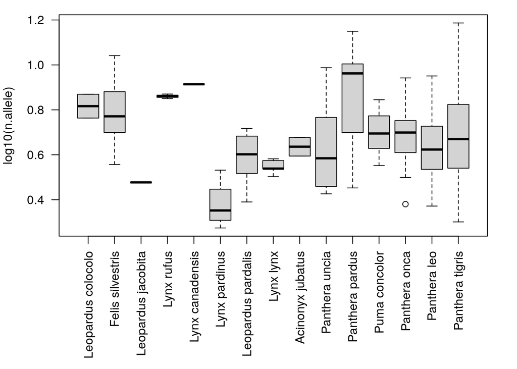

Do the same for the country data set

## GD and DP Relationship within species (Figure S2)

Number of clusters in each species (from lowest to highest)

| Var1 | Freq |
| --- | --- |
| Lynx canadensis | 1 |
| Leopardus colocolo | 2 |
| Leopardus jacobita | 2 |
| Acinonyx jubatus | 2 |
| Lynx pardinus | 4 |
| Lynx rufus | 5 |
| Felis silvestris | 6 |
| Lynx lynx | 7 |
| Leopardus pardalis | 11 |
| Panthera uncia | 14 |
| Puma concolor | 17 |
| Panthera pardus | 20 |
| Panthera tigris | 33 |
| Panthera onca | 44 |
| Panthera leo | 51 |

### GD and PD relationship in 5 species with the most number of clusters

##### a) Panthera pardus

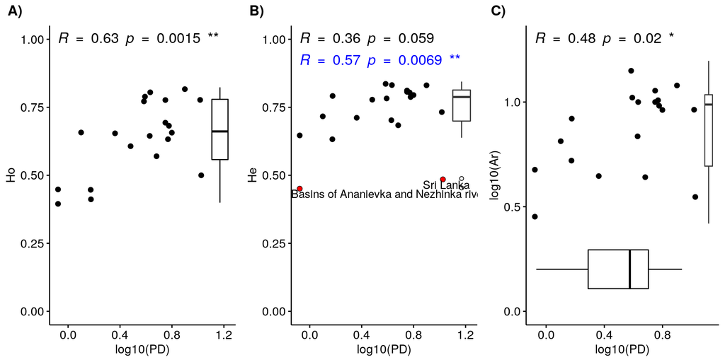

##### b) Panthera tigris

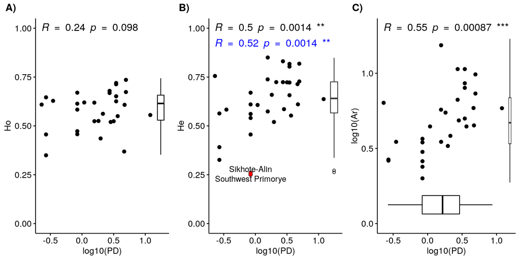

##### c) Panthera onca

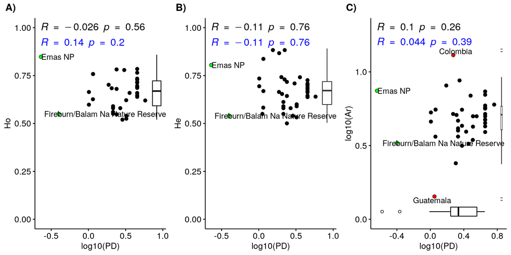

##### d) Panthera leo

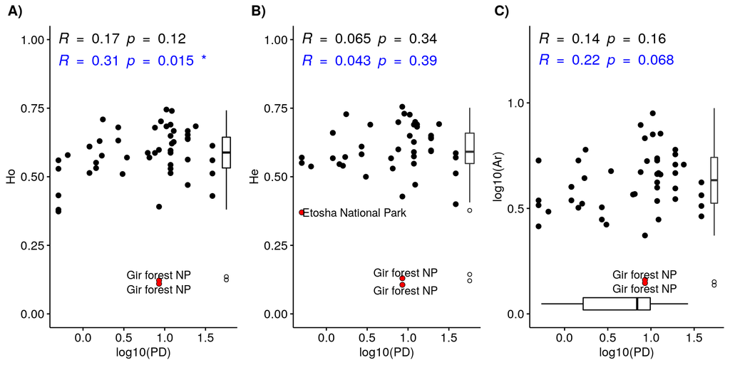

##### e) Puma concolor

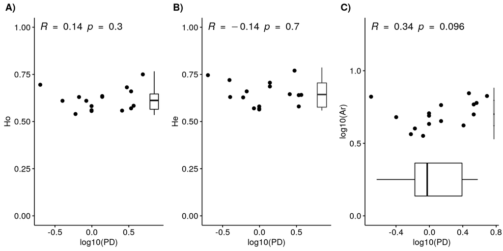

Red points represent the outliers in the GD data whereas green points are the outliers in the PD data.

### Preliminary analyses

#### Using mean estimates per species

```r
clus.mean <- gen_clus %>% group_by(sp) %>% summarise(
  ho = mean(ho, na.rm=T),
  he = mean(he, na.rm=T),
  n.allele = mean(n.allele, na.rm=T),
  dp = mean(DP_mean, na.rm=T),

)

m1 <- lm(ho ~ log10(dp), data= clus.mean)
summary(m1)
```

```
##
## Call:
## lm(formula = ho ~ log10(dp), data = clus.mean)
##
## Residuals:
##       Min        1Q    Median        3Q       Max
## -0.212494 -0.027429 -0.000657  0.066300  0.165915
##
## Coefficients:
##             Estimate Std. Error t value Pr(>|t|)
## (Intercept)  0.58207    0.05015  11.605 7.01e-08 ***
## log10(dp)   -0.01167    0.06166  -0.189    0.853
## ---
## Signif. codes:  0 '***' 0.001 '**' 0.01 '*' 0.05 '.' 0.1 ' ' 1
##
## Residual standard error: 0.1063 on 12 degrees of freedom
##   (1 observation deleted due to missingness)
## Multiple R-squared:  0.002975,   Adjusted R-squared:  -0.08011
## F-statistic: 0.03581 on 1 and 12 DF,  p-value: 0.8531
```

```r
m2 <- lm(he ~ log10(dp), data= clus.mean)
summary(m2)
```

```
##
## Call:
## lm(formula = he ~ log10(dp), data = clus.mean)
##
## Residuals:
##      Min       1Q   Median       3Q      Max
## -0.21164 -0.03496  0.02114  0.05159  0.13611
##
## Coefficients:
##             Estimate Std. Error t value Pr(>|t|)
## (Intercept)  0.60170    0.04647  12.948 8.35e-09 ***
## log10(dp)    0.01739    0.05221   0.333    0.744
## ---
## Signif. codes:  0 '***' 0.001 '**' 0.01 '*' 0.05 '.' 0.1 ' ' 1
##
## Residual standard error: 0.1019 on 13 degrees of freedom
## Multiple R-squared:  0.008459,   Adjusted R-squared:  -0.06781
## F-statistic: 0.1109 on 1 and 13 DF,  p-value: 0.7444
```

```r
m3 <- lm(log10(n.allele) ~ log10(dp), data= clus.mean)
summary(m3)
```

```
##
## Call:
## lm(formula = log10(n.allele) ~ log10(dp), data = clus.mean)
##
## Residuals:
##      Min       1Q   Median       3Q      Max
## -0.30604 -0.07895  0.04248  0.07790  0.21690
##
## Coefficients:
##             Estimate Std. Error t value Pr(>|t|)
## (Intercept)  0.62177    0.06717   9.257 4.37e-07 ***
## log10(dp)    0.10226    0.07546   1.355    0.198
## ---
## Signif. codes:  0 '***' 0.001 '**' 0.01 '*' 0.05 '.' 0.1 ' ' 1
##
## Residual standard error: 0.1473 on 13 degrees of freedom
## Multiple R-squared:  0.1238, Adjusted R-squared:  0.05636
## F-statistic: 1.836 on 1 and 13 DF,  p-value: 0.1985
```

PD effect is nonsignificant when using mean estimates per species

#### Using mean estimates per cluster

```r
clus.mean.1 <- gen_clus %>% group_by(sp, cluster_center) %>% summarise(
  ho = mean(ho, na.rm=T),
  he = mean(he, na.rm=T),
  n.allele = mean(n.allele, na.rm=T),
  dp = mean(DP_mean, na.rm=T),

)
m1 <- lm(ho ~ log10(dp) + sp, data= clus.mean.1)
summary(m1)
```

```
##
## Call:
## lm(formula = ho ~ log10(dp) + sp, data = clus.mean.1)
##
## Residuals:
##      Min       1Q   Median       3Q      Max
## -0.38467 -0.04808  0.00000  0.05345  0.35586
##
## Coefficients:
##                      Estimate Std. Error t value Pr(>|t|)
## (Intercept)           0.53912    0.04620  11.669  < 2e-16 ***
## log10(dp)             0.01291    0.02029   0.636  0.52604
## spLeopardus jacobita -0.16576    0.08624  -1.922  0.05727 .
## spLynx rufus          0.18727    0.06885   2.720  0.00764 **
## spLynx canadensis     0.08841    0.11547   0.766  0.44560
## spLynx pardinus      -0.16568    0.07461  -2.221  0.02851 *
## spLeopardus pardalis  0.03427    0.07571   0.453  0.65173
## spLynx lynx           0.03337    0.06475   0.515  0.60737
## spAcinonyx jubatus    0.11385    0.11264   1.011  0.31444
## spPanthera uncia      0.03294    0.05843   0.564  0.57416
## spPanthera pardus     0.09673    0.05187   1.865  0.06498 .
## spPuma concolor       0.08224    0.05459   1.507  0.13490
## spPanthera onca       0.10765    0.05199   2.071  0.04082 *
## spPanthera leo        0.04115    0.05090   0.808  0.42064
## spPanthera tigris     0.02311    0.05137   0.450  0.65374
## ---
## Signif. codes:  0 '***' 0.001 '**' 0.01 '*' 0.05 '.' 0.1 ' ' 1
##
## Residual standard error: 0.1022 on 106 degrees of freedom
##   (11 observations deleted due to missingness)
## Multiple R-squared:  0.2922, Adjusted R-squared:  0.1987
## F-statistic: 3.126 on 14 and 106 DF,  p-value: 0.0004171
```

```r
anova(m1)
```

|  | Df | Sum Sq | Mean Sq | F value | Pr(>F) |
| --- | --- | --- | --- | --- | --- |
| log10(dp) | 1 | 0.004895822 | 0.004895822 | 0.4690829 | 0.4949043174 |
| sp | 13 | 0.451827176 | 0.034755937 | 3.3300667 | 0.0002770414 |
| Residuals | 106 | 1.106322970 | 0.010437009 | NA | NA |

```r
m2 <- lm(he ~ log10(dp) + sp, data= clus.mean.1)
summary(m2)
```

```
##
## Call:
## lm(formula = he ~ log10(dp) + sp, data = clus.mean.1)
##
## Residuals:
##      Min       1Q   Median       3Q      Max
## -0.37446 -0.06090  0.00061  0.06474  0.20551
##
## Coefficients:
##                       Estimate Std. Error t value Pr(>|t|)
## (Intercept)           0.671326   0.076765   8.745 2.28e-14 ***
## log10(dp)             0.002687   0.020032   0.134   0.8935
## spFelis silvestris   -0.014002   0.084507  -0.166   0.8687
## spLeopardus jacobita -0.250890   0.101843  -2.463   0.0153 *
## spLynx rufus          0.073238   0.088946   0.823   0.4120
## spLynx canadensis     0.013998   0.124430   0.112   0.9106
## spLynx pardinus      -0.268483   0.105958  -2.534   0.0126 *
## spLeopardus pardalis -0.079991   0.092915  -0.861   0.3911
## spLynx lynx          -0.079095   0.088387  -0.895   0.3727
## spAcinonyx jubatus   -0.053801   0.105220  -0.511   0.6101
## spPanthera uncia     -0.054720   0.084072  -0.651   0.5164
## spPanthera pardus     0.063789   0.077234   0.826   0.4106
## spPuma concolor      -0.014124   0.082081  -0.172   0.8637
## spPanthera onca       0.005652   0.077917   0.073   0.9423
## spPanthera leo       -0.078056   0.076009  -1.027   0.3066
## spPanthera tigris    -0.023247   0.078517  -0.296   0.7677
## ---
## Signif. codes:  0 '***' 0.001 '**' 0.01 '*' 0.05 '.' 0.1 ' ' 1
##
## Residual standard error: 0.1014 on 114 degrees of freedom
##   (2 observations deleted due to missingness)
## Multiple R-squared:  0.3096, Adjusted R-squared:  0.2187
## F-statistic: 3.408 on 15 and 114 DF,  p-value: 9.061e-05
```

```r
anova(m2)
```

|  | Df | Sum Sq | Mean Sq | F value | Pr(>F) |
| --- | --- | --- | --- | --- | --- |
| log10(dp) | 1 | 0.001344156 | 0.001344156 | 0.1306944 | 7.183823e-01 |
| sp | 14 | 0.524360424 | 0.037454316 | 3.6417421 | 5.364133e-05 |
| Residuals | 114 | 1.172458662 | 0.010284725 | NA | NA |

```r
m3 <- lm(log10(n.allele) ~ log10(dp) + sp, data= clus.mean.1)
summary(m3)
```

```
##
## Call:
## lm(formula = log10(n.allele) ~ log10(dp) + sp, data = clus.mean.1)
##
## Residuals:
##      Min       1Q   Median       3Q      Max
## -0.51464 -0.08985  0.00949  0.09639  0.43577
##
## Coefficients:
##                       Estimate Std. Error t value Pr(>|t|)
## (Intercept)           0.762786   0.123281   6.187 1.03e-08 ***
## log10(dp)             0.039153   0.031420   1.246   0.2153
## spFelis silvestris    0.003274   0.136028   0.024   0.9808
## spLeopardus jacobita -0.320951   0.164068  -1.956   0.0529 .
## spLynx rufus          0.041689   0.143229   0.291   0.7715
## spLynx canadensis     0.082888   0.200481   0.413   0.6801
## spLynx pardinus      -0.373648   0.152888  -2.444   0.0161 *
## spLeopardus pardalis -0.165377   0.149690  -1.105   0.2716
## spLynx lynx          -0.201010   0.142129  -1.414   0.1601
## spAcinonyx jubatus   -0.125664   0.169229  -0.743   0.4593
## spPanthera uncia     -0.097101   0.135147  -0.718   0.4740
## spPanthera pardus     0.090732   0.124628   0.728   0.4681
## spPuma concolor      -0.065559   0.130980  -0.501   0.6177
## spPanthera onca      -0.095347   0.125529  -0.760   0.4491
## spPanthera leo       -0.163989   0.122372  -1.340   0.1829
## spPanthera tigris    -0.064941   0.126676  -0.513   0.6092
## ---
## Signif. codes:  0 '***' 0.001 '**' 0.01 '*' 0.05 '.' 0.1 ' ' 1
##
## Residual standard error: 0.1634 on 112 degrees of freedom
##   (4 observations deleted due to missingness)
## Multiple R-squared:  0.3156, Adjusted R-squared:  0.2239
## F-statistic: 3.443 on 15 and 112 DF,  p-value: 8.145e-05
```

```r
anova(m3)
```

|  | Df | Sum Sq | Mean Sq | F value | Pr(>F) |
| --- | --- | --- | --- | --- | --- |
| log10(dp) | 1 | 0.09821693 | 0.09821693 | 3.678029 | 0.0576805614 |
| sp | 14 | 1.28096545 | 0.09149753 | 3.426401 | 0.0001246441 |
| Residuals | 112 | 2.99081226 | 0.02670368 | NA | NA |

Species effect is significant when using the estimated mean response variable per cluster

## Modeling the relationship between GD and PD

### Simple LME models (no covariates)

#### 1. Cluster dataset

- *Ho*

```r
library(lmerTest)
df_Ho <- subset(gen_clus, !is.na(ho) & ho < 1)

Ho.lmer <- lmer(ho ~ DP_log + (1|sp), data = df_Ho[!df_Ho$ho_out & !df_Ho$dp_out,],  REML=F)
summary(Ho.lmer)
```

```
## Linear mixed model fit by maximum likelihood . t-tests use Satterthwaite's
##   method [lmerModLmerTest]
## Formula: ho ~ DP_log + (1 | sp)
##    Data: df_Ho[!df_Ho$ho_out & !df_Ho$dp_out, ]
##
##      AIC      BIC   logLik deviance df.resid
##   -349.9   -336.8    178.9   -357.9      188
##
## Scaled residuals:
##     Min      1Q  Median      3Q     Max
## -2.6388 -0.6939  0.1580  0.6596  1.8959
##
## Random effects:
##  Groups   Name        Variance Std.Dev.
##  sp       (Intercept) 0.007525 0.08675
##  Residual             0.007753 0.08805
## Number of obs: 192, groups:  sp, 14
##
## Fixed effects:
##              Estimate Std. Error        df t value Pr(>|t|)
## (Intercept)   0.55198    0.02654  12.69370   20.80 3.48e-11 ***
## DP_log        0.05054    0.01465 190.40741    3.45  0.00069 ***
## ---
## Signif. codes:  0 '***' 0.001 '**' 0.01 '*' 0.05 '.' 0.1 ' ' 1
##
## Correlation of Fixed Effects:
##        (Intr)
## DP_log -0.258
```

- *Ho + outliers*

```r
Ho.lmer.out <- lmer(ho ~ DP_log + (1|sp), data = df_Ho,  REML=F)
summary(Ho.lmer.out)
```

```
## Linear mixed model fit by maximum likelihood . t-tests use Satterthwaite's
##   method [lmerModLmerTest]
## Formula: ho ~ DP_log + (1 | sp)
##    Data: df_Ho
##
##      AIC      BIC   logLik deviance df.resid
##   -300.5   -287.3    154.3   -308.5      199
##
## Scaled residuals:
##     Min      1Q  Median      3Q     Max
## -4.3504 -0.5267  0.1652  0.6173  3.5087
##
## Random effects:
##  Groups   Name        Variance Std.Dev.
##  sp       (Intercept) 0.005485 0.07406
##  Residual             0.011395 0.10675
## Number of obs: 203, groups:  sp, 14
##
## Fixed effects:
##              Estimate Std. Error        df t value Pr(>|t|)
## (Intercept)   0.56074    0.02413  10.99336  23.238 1.07e-10 ***
## DP_log        0.03581    0.01601 202.86712   2.237   0.0264 *
## ---
## Signif. codes:  0 '***' 0.001 '**' 0.01 '*' 0.05 '.' 0.1 ' ' 1
##
## Correlation of Fixed Effects:
##        (Intr)
## DP_log -0.295
```

- *He*

```r
df_He <- subset(gen_clus, !is.na(he) & he < 1 & he > 0)
He.lmer <- lmer(he ~ DP_log + (1|sp), data = df_He[!df_He$he_out & !df_He$dp_out,], REML=F)
summary(He.lmer)
```

```
## Linear mixed model fit by maximum likelihood . t-tests use Satterthwaite's
##   method [lmerModLmerTest]
## Formula: he ~ DP_log + (1 | sp)
##    Data: df_He[!df_He$he_out & !df_He$dp_out, ]
##
##      AIC      BIC   logLik deviance df.resid
##   -344.3   -331.2    176.1   -352.3      191
##
## Scaled residuals:
##     Min      1Q  Median      3Q     Max
## -3.3023 -0.5776 -0.0298  0.6196  2.4276
##
## Random effects:
##  Groups   Name        Variance Std.Dev.
##  sp       (Intercept) 0.006414 0.08009
##  Residual             0.008291 0.09106
## Number of obs: 195, groups:  sp, 15
##
## Fixed effects:
##              Estimate Std. Error        df t value Pr(>|t|)
## (Intercept)   0.61425    0.02474  14.14616  24.826 4.57e-13 ***
## DP_log        0.02432    0.01588 194.26646   1.531    0.127
## ---
## Signif. codes:  0 '***' 0.001 '**' 0.01 '*' 0.05 '.' 0.1 ' ' 1
##
## Correlation of Fixed Effects:
##        (Intr)
## DP_log -0.327
```

- *He + outliers*

```r
He.lmer.out <- lmer(he ~ DP_log + (1|sp), data = df_He, REML=F)
summary(He.lmer.out)
```

```
## Linear mixed model fit by maximum likelihood . t-tests use Satterthwaite's
##   method [lmerModLmerTest]
## Formula: he ~ DP_log + (1 | sp)
##    Data: df_He
##
##      AIC      BIC   logLik deviance df.resid
##   -283.9   -270.6    146.0   -291.9      205
##
## Scaled residuals:
##     Min      1Q  Median      3Q     Max
## -4.1691 -0.4626  0.0156  0.6573  1.9770
##
## Random effects:
##  Groups   Name        Variance Std.Dev.
##  sp       (Intercept) 0.003664 0.06053
##  Residual             0.013230 0.11502
## Number of obs: 209, groups:  sp, 15
##
## Fixed effects:
##              Estimate Std. Error        df t value Pr(>|t|)
## (Intercept)   0.61441    0.02124  12.31464  28.931 1.07e-12 ***
## DP_log        0.01983    0.01716 200.82946   1.155    0.249
## ---
## Signif. codes:  0 '***' 0.001 '**' 0.01 '*' 0.05 '.' 0.1 ' ' 1
##
## Correlation of Fixed Effects:
##        (Intr)
## DP_log -0.375
```

- *allelic richness*

```r
#log transform n.allele to meet the normality of error term assumptions
gen_clus$n.allele_log <- log10(gen_clus$n.allele)

df_mna <- subset(gen_clus, !is.na(n.allele))
mna.lmer <- lmer(n.allele_log ~ DP_log + (1|sp), data = df_mna[!df_mna$ar_out & !df_mna$dp_out,], REML=FALSE)
summary(mna.lmer)
```

```
## Linear mixed model fit by maximum likelihood . t-tests use Satterthwaite's
##   method [lmerModLmerTest]
## Formula: n.allele_log ~ DP_log + (1 | sp)
##    Data: df_mna[!df_mna$ar_out & !df_mna$dp_out, ]
##
##      AIC      BIC   logLik deviance df.resid
##   -157.6   -144.4     82.8   -165.6      193
##
## Scaled residuals:
##     Min      1Q  Median      3Q     Max
## -2.4184 -0.6347 -0.0073  0.5809  3.3685
##
## Random effects:
##  Groups   Name        Variance Std.Dev.
##  sp       (Intercept) 0.01152  0.1073
##  Residual             0.02230  0.1493
## Number of obs: 197, groups:  sp, 15
##
## Fixed effects:
##              Estimate Std. Error        df t value Pr(>|t|)
## (Intercept)   0.63355    0.03490  15.39318  18.152 8.26e-12 ***
## DP_log        0.07914    0.02432 196.55092   3.254  0.00134 **
## ---
## Signif. codes:  0 '***' 0.001 '**' 0.01 '*' 0.05 '.' 0.1 ' ' 1
##
## Correlation of Fixed Effects:
##        (Intr)
## DP_log -0.367
```

- *allelic richness + outliers*

```r
mna.lmer.out <- lmer(n.allele_log ~ DP_log + (1|sp), data = df_mna, REML=FALSE)
summary(mna.lmer.out)
```

```
## Linear mixed model fit by maximum likelihood . t-tests use Satterthwaite's
##   method [lmerModLmerTest]
## Formula: n.allele_log ~ DP_log + (1 | sp)
##    Data: df_mna
##
##      AIC      BIC   logLik deviance df.resid
##   -133.1   -119.8     70.6   -141.1      204
##
## Scaled residuals:
##      Min       1Q   Median       3Q      Max
## -3.10630 -0.62325 -0.01382  0.58340  3.08003
##
## Random effects:
##  Groups   Name        Variance Std.Dev.
##  sp       (Intercept) 0.01054  0.1027
##  Residual             0.02666  0.1633
## Number of obs: 208, groups:  sp, 15
##
## Fixed effects:
##              Estimate Std. Error        df t value Pr(>|t|)
## (Intercept)   0.64192    0.03394  14.98640  18.914 7.19e-12 ***
## DP_log        0.06439    0.02412 207.92034   2.669   0.0082 **
## ---
## Signif. codes:  0 '***' 0.001 '**' 0.01 '*' 0.05 '.' 0.1 ' ' 1
##
## Correlation of Fixed Effects:
##        (Intr)
## DP_log -0.358
```

#### 2. Country dataset

- *Ho*

```r
df_Ho.c <- subset(gen_count, !is.na(ho) & ho < 1)

Ho.c.lmer <- lmer(ho ~ DP_log + (1|sp), data = df_Ho.c[!df_Ho.c$ho_out & !df_Ho.c$dp_out,],  REML=F)
summary(Ho.c.lmer)
```

```
## Linear mixed model fit by maximum likelihood . t-tests use Satterthwaite's
##   method [lmerModLmerTest]
## Formula: ho ~ DP_log + (1 | sp)
##    Data: df_Ho.c[!df_Ho.c$ho_out & !df_Ho.c$dp_out, ]
##
##      AIC      BIC   logLik deviance df.resid
##   -718.0   -702.3    363.0   -726.0      365
##
## Scaled residuals:
##     Min      1Q  Median      3Q     Max
## -2.7068 -0.6339  0.0914  0.6319  2.2657
##
## Random effects:
##  Groups   Name        Variance Std.Dev.
##  sp       (Intercept) 0.008404 0.09167
##  Residual             0.007267 0.08524
## Number of obs: 369, groups:  sp, 17
##
## Fixed effects:
##              Estimate Std. Error        df t value Pr(>|t|)
## (Intercept)   0.52678    0.02662  21.26621  19.791 3.51e-15 ***
## DP_log        0.07462    0.01813 261.20149   4.116 5.17e-05 ***
## ---
## Signif. codes:  0 '***' 0.001 '**' 0.01 '*' 0.05 '.' 0.1 ' ' 1
##
## Correlation of Fixed Effects:
##        (Intr)
## DP_log -0.439
```

- *Ho + outliers*

```r
Ho.c.lmer.out <- lmer(ho ~ DP_log + (1|sp), data = df_Ho.c,  REML=F)
summary(Ho.c.lmer.out)
```

```
## Linear mixed model fit by maximum likelihood . t-tests use Satterthwaite's
##   method [lmerModLmerTest]
## Formula: ho ~ DP_log + (1 | sp)
##    Data: df_Ho.c
##
##      AIC      BIC   logLik deviance df.resid
##   -680.4   -664.4    344.2   -688.4      401
##
## Scaled residuals:
##     Min      1Q  Median      3Q     Max
## -4.6623 -0.5700  0.1250  0.6109  4.0484
##
## Random effects:
##  Groups   Name        Variance Std.Dev.
##  sp       (Intercept) 0.006232 0.07894
##  Residual             0.009770 0.09885
## Number of obs: 405, groups:  sp, 17
##
## Fixed effects:
##              Estimate Std. Error        df t value Pr(>|t|)
## (Intercept)   0.55694    0.02321  18.58929  23.992 1.91e-15 ***
## DP_log        0.03266    0.01518 315.21960   2.152   0.0322 *
## ---
## Signif. codes:  0 '***' 0.001 '**' 0.01 '*' 0.05 '.' 0.1 ' ' 1
##
## Correlation of Fixed Effects:
##        (Intr)
## DP_log -0.392
```

- *He*

```r
df_He.c <- subset(gen_count, !is.na(he) & he < 1 & he > 0)
He.c.lmer <- lmer(he ~ DP_log + (1|sp), data = df_He.c[!df_He.c$he_out & !df_He.c$dp_out,], REML=F)
summary(He.c.lmer)
```

```
## Linear mixed model fit by maximum likelihood . t-tests use Satterthwaite's
##   method [lmerModLmerTest]
## Formula: he ~ DP_log + (1 | sp)
##    Data: df_He.c[!df_He.c$he_out & !df_He.c$dp_out, ]
##
##      AIC      BIC   logLik deviance df.resid
##   -867.2   -851.2    437.6   -875.2      399
##
## Scaled residuals:
##     Min      1Q  Median      3Q     Max
## -3.6005 -0.4386  0.0351  0.5229  3.5148
##
## Random effects:
##  Groups   Name        Variance Std.Dev.
##  sp       (Intercept) 0.008819 0.09391
##  Residual             0.005865 0.07659
## Number of obs: 403, groups:  sp, 18
##
## Fixed effects:
##              Estimate Std. Error        df t value Pr(>|t|)
## (Intercept)   0.59988    0.02614  21.95273  22.947  < 2e-16 ***
## DP_log        0.04363    0.01643 313.26516   2.655  0.00834 **
## ---
## Signif. codes:  0 '***' 0.001 '**' 0.01 '*' 0.05 '.' 0.1 ' ' 1
##
## Correlation of Fixed Effects:
##        (Intr)
## DP_log -0.442
```

- *He + outliers*

```r
He.c.lmer.out <- lmer(he ~ DP_log + (1|sp), data = df_He.c, REML=F)
summary(He.c.lmer.out)
```

```
## Linear mixed model fit by maximum likelihood . t-tests use Satterthwaite's
##   method [lmerModLmerTest]
## Formula: he ~ DP_log + (1 | sp)
##    Data: df_He.c
##
##      AIC      BIC   logLik deviance df.resid
##   -674.1   -657.6    341.1   -682.1      457
##
## Scaled residuals:
##     Min      1Q  Median      3Q     Max
## -4.4017 -0.3224  0.1454  0.5310  2.5142
##
## Random effects:
##  Groups   Name        Variance Std.Dev.
##  sp       (Intercept) 0.005767 0.07594
##  Residual             0.012338 0.11107
## Number of obs: 461, groups:  sp, 18
##
## Fixed effects:
##              Estimate Std. Error        df t value Pr(>|t|)
## (Intercept)   0.60311    0.02298  17.89617  26.247 9.74e-16 ***
## DP_log        0.04071    0.01610 260.04318   2.529    0.012 *
## ---
## Signif. codes:  0 '***' 0.001 '**' 0.01 '*' 0.05 '.' 0.1 ' ' 1
##
## Correlation of Fixed Effects:
##        (Intr)
## DP_log -0.458
```

- *allelic richness*

```r
#log transform n.allele to meet the normality of error term assumptions
gen_count$n.allele_log <- log10(gen_count$n.allele)
df_mna.c <- subset(gen_count, !is.na(n.allele))
mna.c.lmer <- lmer(n.allele_log ~ DP_log + (1|sp), data = df_mna.c[!df_mna.c$ar_out & !df_mna.c$dp_out,], REML=FALSE)
summary(mna.c.lmer)
```

```
## Linear mixed model fit by maximum likelihood . t-tests use Satterthwaite's
##   method [lmerModLmerTest]
## Formula: n.allele_log ~ DP_log + (1 | sp)
##    Data: df_mna.c[!df_mna.c$ar_out & !df_mna.c$dp_out, ]
##
##      AIC      BIC   logLik deviance df.resid
##   -441.6   -425.7    224.8   -449.6      387
##
## Scaled residuals:
##     Min      1Q  Median      3Q     Max
## -2.8029 -0.5619 -0.0293  0.5683  3.5636
##
## Random effects:
##  Groups   Name        Variance Std.Dev.
##  sp       (Intercept) 0.01045  0.1022
##  Residual             0.01685  0.1298
## Number of obs: 391, groups:  sp, 17
##
## Fixed effects:
##              Estimate Std. Error        df t value Pr(>|t|)
## (Intercept)   0.58661    0.03268  23.36783  17.950 3.61e-15 ***
## DP_log        0.13650    0.02578 172.11005   5.295 3.60e-07 ***
## ---
## Signif. codes:  0 '***' 0.001 '**' 0.01 '*' 0.05 '.' 0.1 ' ' 1
##
## Correlation of Fixed Effects:
##        (Intr)
## DP_log -0.552
```

- *allelic richness + outliers*

```r
mna.c.lmer.out <- lmer(n.allele_log ~ DP_log + (1|sp), data = df_mna.c, REML=FALSE)
summary(mna.c.lmer.out)
```

```
## Linear mixed model fit by maximum likelihood . t-tests use Satterthwaite's
##   method [lmerModLmerTest]
## Formula: n.allele_log ~ DP_log + (1 | sp)
##    Data: df_mna.c
##
##      AIC      BIC   logLik deviance df.resid
##   -340.9   -324.6    174.5   -348.9      434
##
## Scaled residuals:
##     Min      1Q  Median      3Q     Max
## -3.4123 -0.4865  0.0598  0.5798  3.0560
##
## Random effects:
##  Groups   Name        Variance Std.Dev.
##  sp       (Intercept) 0.01018  0.1009
##  Residual             0.02448  0.1565
## Number of obs: 438, groups:  sp, 17
##
## Fixed effects:
##              Estimate Std. Error        df t value Pr(>|t|)
## (Intercept)   0.62445    0.03150  19.88485  19.821 1.45e-14 ***
## DP_log        0.08862    0.02294 258.73820   3.862 0.000142 ***
## ---
## Signif. codes:  0 '***' 0.001 '**' 0.01 '*' 0.05 '.' 0.1 ' ' 1
##
## Correlation of Fixed Effects:
##        (Intr)
## DP_log -0.478
```

All 3 GD models showed significant effect of PD

## Includes covariates

1. Cluster final models
- **Ho**

```r
library(MuMIn)
library(performance)


df <- df_Ho[!df_Ho$ho_out & !df_Ho$dp_out,]
df$GL  <- df$GenerationLength_d
```

scale all covariates to have mean = 0 and standard deviation = 1

```r
df <- df %>% mutate_at(c("DP_log","GL","BS_log","sample.size_log"), ~(scale(.) %>% as.vector))
```

using step-wise approach that is by adding more factor, from highest to lowest effect size

```r
for (i in 1:4) {
  var <- c("DP_log","GL","BS_log","sample.size_log")
  print(fixef(lmer(paste("ho ~", var[i], "+ (1|sp)"), data=df))[2])

}
```

```
##    DP_log
## 0.0263541
##        GL
## 0.0629699
##     BS_log
## 0.02028376
## sample.size_log
##      0.01953229
```

```r
null_Ho <- lmer(ho ~ 1 + (1|sp), data = df, REML = F)
full_Ho <- update(null_Ho, . ~ . + GL)
full_Ho_1 <- update(full_Ho, . ~ . + DP_log)
full_Ho_2 <- update(full_Ho_1, . ~ . + BS_log)
full_Ho_3 <- update(full_Ho_2, . ~ . + sample.size_log)
compare_performance(null_Ho, full_Ho, full_Ho_1, full_Ho_2, full_Ho_3, rank = TRUE)
```

| Name | Model | R2_conditional | R2_marginal | ICC | RMSE | Sigma | AIC_wt | BIC_wt | Performance_Score |
| --- | --- | --- | --- | --- | --- | --- | --- | --- | --- |
| full_Ho_1 | lmerModLmerTest | 0.4354873 | 0.2961702 | 0.1979414 | 0.08616824 | 0.08813830 | 1.072607e-01 | 0.6251303982 | 0.6635199 |
| full_Ho_3 | lmerModLmerTest | 0.3876532 | 0.3078040 | 0.1153564 | 0.08589194 | 0.08746763 | 7.280500e-01 | 0.1632972595 | 0.6086665 |
| full_Ho_2 | lmerModLmerTest | 0.3921182 | 0.2954669 | 0.1371848 | 0.08657452 | 0.08828510 | 1.638877e-01 | 0.1873786429 | 0.4461867 |
| null_Ho | lmerModLmerTest | 0.4685597 | 0.0000000 | 0.4685597 | 0.08827719 | 0.09098939 | 3.100890e-06 | 0.0004696006 | 0.3058654 |
| full_Ho | lmerModLmerTest | 0.4238430 | 0.2708945 | 0.2097755 | 0.08866890 | 0.09074091 | 7.985528e-04 | 0.0237240988 | 0.2433701 |

```r
options(na.action = na.fail)
dr_Ho <- dredge(full_Ho_3, fixed=~(1|sp),
                rank = "AIC", extra = list("R2M" = function(x) {r.squaredGLMM(x)[1]}, "R2C" = function(x) r.squaredGLMM(x)[2], "var. sp" = function(x) as.numeric(insight::get_variance_random(x))))
```

```
## Fixed term is "(Intercept)"
```

```r
# Set as data.frame
dredge2df <- function(dr){
   dr.df <- as.data.frame(dr)
   dr.df$Model <- rownames(dr.df)
   for(i in 1:nrow(dr.df)) {
     form <- formula(paste(attr(dr,"model.calls")[[i]])[2])

     dr.df$Model[i] <- as.character(form)[3]
   }
   dr.df$Model <- gsub(" \\+ \\(1 \\| sp\\)", "", dr.df$Model)

   dr.df <- dr.df[,c(ncol(dr.df),1:ncol(dr.df)-1)]
   dr.df
}

dr_Ho.df <- dredge2df(dr=dr_Ho)
```

|  | Model | (Intercept) | BS_log | DP_log | GL | sample.size_log | R2M | R2C | var. sp | df | logLik | AIC | delta | weight |
| --- | --- | --- | --- | --- | --- | --- | --- | --- | --- | --- | --- | --- | --- | --- |
| 16 | BS_log + DP_log + GL + sample.size_log | 0.59 | 0.02 | 0.02 | 0.06 | 0.02 | 0.31 | 0.39 | 0.00 | 7 | 189.55 | -365.10 | 0.00 | 5.107938e-01 |
| 15 | DP_log + GL + sample.size_log | 0.58 | NA | 0.02 | 0.06 | 0.02 | 0.31 | 0.43 | 0.00 | 6 | 187.96 | -363.91 | 1.18 | 2.826879e-01 |
| 8 | BS_log + DP_log + GL | 0.59 | 0.02 | 0.03 | 0.06 | NA | 0.30 | 0.39 | 0.00 | 6 | 187.06 | -362.11 | 2.98 | 1.149822e-01 |
| 7 | DP_log + GL | 0.58 | NA | 0.03 | 0.06 | NA | 0.30 | 0.44 | 0.00 | 5 | 185.63 | -361.26 | 3.83 | 7.525321e-02 |
| 13 | GL + sample.size_log | 0.58 | NA | NA | 0.06 | 0.02 | 0.29 | 0.42 | 0.00 | 5 | 183.20 | -356.41 | 8.69 | 6.631191e-03 |
| 14 | BS_log + GL + sample.size_log | 0.59 | 0.02 | NA | 0.06 | 0.02 | 0.28 | 0.38 | 0.00 | 6 | 184.11 | -356.23 | 8.87 | 6.056093e-03 |
| 11 | DP_log + sample.size_log | 0.58 | NA | 0.02 | NA | 0.02 | 0.06 | 0.49 | 0.01 | 5 | 181.42 | -352.84 | 12.25 | 1.115502e-03 |
| 12 | BS_log + DP_log + sample.size_log | 0.60 | 0.03 | 0.02 | NA | 0.02 | 0.10 | 0.48 | 0.01 | 6 | 182.29 | -352.59 | 12.51 | 9.833230e-04 |
| 5 | GL | 0.58 | NA | NA | 0.06 | NA | 0.27 | 0.42 | 0.00 | 4 | 179.73 | -351.46 | 13.63 | 5.602579e-04 |
| 6 | BS_log + GL | 0.59 | 0.02 | NA | 0.06 | NA | 0.26 | 0.39 | 0.00 | 5 | 180.45 | -350.90 | 14.20 | 4.221535e-04 |
| 3 | DP_log | 0.58 | NA | 0.03 | NA | NA | 0.04 | 0.51 | 0.01 | 4 | 178.94 | -349.88 | 15.22 | 2.532719e-04 |
| 4 | BS_log + DP_log | 0.60 | 0.03 | 0.03 | NA | NA | 0.09 | 0.51 | 0.01 | 5 | 179.73 | -349.47 | 15.63 | 2.066092e-04 |
| 9 | sample.size_log | 0.58 | NA | NA | NA | 0.02 | 0.03 | 0.44 | 0.01 | 4 | 176.84 | -345.67 | 19.42 | 3.097207e-05 |
| 10 | BS_log + sample.size_log | 0.59 | 0.02 | NA | NA | 0.02 | 0.06 | 0.44 | 0.01 | 5 | 177.40 | -344.81 | 20.29 | 2.006710e-05 |
| 1 | (1 \| sp) | 0.58 | NA | NA | NA | NA | 0.00 | 0.47 | 0.01 | 3 | 173.18 | -340.36 | 24.73 | 2.175559e-06 |
| 2 | BS_log | 0.59 | 0.02 | NA | NA | NA | 0.03 | 0.46 | 0.01 | 4 | 173.64 | -339.29 | 25.81 | 1.269544e-06 |

Model selection - most parsimonious that is the one with the least AIC

```r
best_Ho <- lmer(formula=formula(attr(dr_Ho[1], "model.calls")[[1]]), df)
summary(best_Ho)
```

```
## Linear mixed model fit by REML. t-tests use Satterthwaite's method [
## lmerModLmerTest]
## Formula: formula(attr(dr_Ho[1], "model.calls")[[1]])
##    Data: df
##
## REML criterion at convergence: -342.1
##
## Scaled residuals:
##     Min      1Q  Median      3Q     Max
## -2.8340 -0.6103  0.1322  0.6659  1.8556
##
## Random effects:
##  Groups   Name        Variance Std.Dev.
##  sp       (Intercept) 0.001724 0.04152
##  Residual             0.007710 0.08780
## Number of obs: 192, groups:  sp, 14
##
## Fixed effects:
##                  Estimate Std. Error        df t value Pr(>|t|)
## (Intercept)     5.943e-01  1.662e-02 5.127e+00  35.751 2.39e-07 ***
## BS_log          2.010e-02  1.234e-02 8.375e+00   1.629  0.14031
## DP_log          2.417e-02  7.438e-03 1.757e+02   3.250  0.00138 **
## GL              5.718e-02  1.332e-02 1.094e+01   4.293  0.00129 **
## sample.size_log 1.516e-02  7.040e-03 1.869e+02   2.154  0.03253 *
## ---
## Signif. codes:  0 '***' 0.001 '**' 0.01 '*' 0.05 '.' 0.1 ' ' 1
##
## Correlation of Fixed Effects:
##             (Intr) BS_log DP_log GL
## BS_log       0.492
## DP_log       0.068  0.101
## GL          -0.031 -0.044  0.019
## sampl.sz_lg -0.002 -0.004 -0.169 -0.124
```

Remove outliers; thoses with low PD but high GD

```r
foo <- df[df$DP_log %in% head(sort(df$DP_log),5),]
foo[order(foo$DP_log),]
```

|  | sp | country | population.gen | population.den | cluster_center | sample.size | ho | he | n.allele | DP_max | DP_mean | BS | GenerationLength_d | ref.gen | ref.den | n.allele_log | sample.size_log | DP_log | BS_log | ho_out | he_out | ar_out | dp_out | label | GL |
| --- | --- | --- | --- | --- | --- | --- | --- | --- | --- | --- | --- | --- | --- | --- | --- | --- | --- | --- | --- | --- | --- | --- | --- | --- | --- |
| 204 | Puma concolor | Brazil | Rio Grande do Sul, Santa Catarina, and Parano | Yaboti Biosphere Reserve | 1_NT | 32.375 | 0.6951250 | 0.7458750 | 6.625000 | 0.20 | 0.20 | 44.8 | 2693.79 | castilho_genetic_2012 | Rich_Journal of Mammology_2014 | 0.8211859 | 0.6673001 | -2.248868 | -0.4079783 | FALSE | FALSE | FALSE | FALSE | atop(italic(.concolor),Rio~Grande~do~Sul,~Santa~Catarina,~and~Parano) | -0.31378874 |
| 159 | Panthera tigris | Bhutan | Whole Bhutan | Bhutan | 65_IM | 13.000 | 0.6090909 | 0.7554545 | 6.363636 | 0.23 | 0.23 | 190.5 | 2920.00 | dhendup_tiger_2019 | Tempa_Thesis_2017 | 0.8037054 | -0.4213177 | -2.132195 | 1.0626799 | FALSE | FALSE | FALSE | FALSE | atop(italic(.tigris),Whole~Bhutan) | 0.07939315 |
| 160 | Panthera tigris | China | Northeast China | Hunchun National Nature Reserve | 3_PA | 11.000 | 0.4562500 | 0.3912500 | 2.625000 | 0.30 | 0.27 | 190.5 | 2920.00 | dou_estimating_2016 | Xiao_Integrative Zoology_2016 | 0.4191293 | -0.6206279 | -1.998341 | 1.0626799 | FALSE | FALSE | FALSE | FALSE | atop(italic(.tigris),Northeast~China) | 0.07939315 |
| 169 | Panthera tigris | China | Changbai mountain | Hunchun National Nature Reserve | 3_PA | 15.000 | 0.6462500 | 0.5637500 | NaN | 0.30 | 0.27 | 190.5 | 2920.00 | ning_dispersal_2019 | Xiao_Integrative Zoology_2016 | NaN | -0.2505858 | -1.998341 | 1.0626799 | FALSE | FALSE | FALSE | FALSE | atop(italic(.tigris),Changbai~mountain) | 0.07939315 |
| 185 | Panthera tigris | China | Hunchun NR | Hunchun National Nature Reserve | 3_PA | 24.000 | 0.3495000 | 0.3260000 | 2.666667 | 0.30 | 0.27 | 190.5 | 2920.00 | wang_noninvasive_2016 | Xiao_Integrative Zoology_2016 | 0.4259687 | 0.3101699 | -1.998341 | 1.0626799 | FALSE | FALSE | FALSE | FALSE | atop(italic(.tigris),Hunchun~NR) | 0.07939315 |

```r
best_Ho.1 <- update(best_Ho, data=df[!rownames(df) %in% c(204,159,169),])
broom.mixed::tidy(best_Ho.1)
```

| effect | group | term | estimate | std.error | statistic | df | p.value |
| --- | --- | --- | --- | --- | --- | --- | --- |
| fixed | NA | (Intercept) | 0.59262347 | 0.016285267 | 36.390160 | 4.974704 | 3.133820e-07 |
| fixed | NA | BS_log | 0.01969689 | 0.012127242 | 1.624185 | 8.199011 | 1.420741e-01 |
| fixed | NA | DP_log | 0.02820722 | 0.007621166 | 3.701169 | 172.247883 | 2.885596e-04 |
| fixed | NA | GL | 0.05737225 | 0.013106935 | 4.377244 | 10.660911 | 1.188758e-03 |
| fixed | NA | sample.size_log | 0.01495618 | 0.007028571 | 2.127913 | 183.853282 | 3.467662e-02 |
| ran_pars | sp | sd__(Intercept) | 0.04048472 | NA | NA | NA | NA |
| ran_pars | Residual | sd__Observation | 0.08742770 | NA | NA | NA | NA |

Remove lion data, to verify whether the methods to estimate PD can influence the relationship

```r
summary(update(best_Ho, data=df[which(df$sp != "Panthera leo"),]))
```

```
## Linear mixed model fit by REML. t-tests use Satterthwaite's method [
## lmerModLmerTest]
## Formula: formula(attr(dr_Ho[1], "model.calls")[[1]])
##    Data: df[which(df$sp != "Panthera leo"), ]
##
## REML criterion at convergence: -242.1
##
## Scaled residuals:
##     Min      1Q  Median      3Q     Max
## -2.7423 -0.5942  0.2473  0.6355  1.8641
##
## Random effects:
##  Groups   Name        Variance Std.Dev.
##  sp       (Intercept) 0.001570 0.03963
##  Residual             0.008012 0.08951
## Number of obs: 143, groups:  sp, 13
##
## Fixed effects:
##                  Estimate Std. Error        df t value Pr(>|t|)
## (Intercept)     5.824e-01  1.976e-02 4.776e+00  29.475 1.37e-06 ***
## BS_log          1.265e-02  1.419e-02 7.196e+00   0.892 0.401233
## DP_log          2.360e-02  1.006e-02 1.268e+02   2.346 0.020532 *
## GL              6.442e-02  1.488e-02 1.231e+01   4.330 0.000923 ***
## sample.size_log 1.444e-02  8.703e-03 1.349e+02   1.659 0.099356 .
## ---
## Signif. codes:  0 '***' 0.001 '**' 0.01 '*' 0.05 '.' 0.1 ' ' 1
##
## Correlation of Fixed Effects:
##             (Intr) BS_log DP_log GL
## BS_log       0.637
## DP_log       0.217  0.240
## GL          -0.296 -0.273 -0.102
## sampl.sz_lg  0.001  0.000 -0.114 -0.135
```

```r
# No differences
```

- **He**

```r
for (i in 1:4) {
  var <- c("DP_log","GL","BS_log","sample.size_log")
  print(fixef(lmer(paste("he ~", var[i], "+ (1|sp)"), data=df ))[2])

}
```

```
##     DP_log
## 0.01259768
##         GL
## 0.05965221
##     BS_log
## 0.01259522
## sample.size_log
##      0.02619554
```

```r
null_He <- lmer(he ~ 1 + (1|sp), data = df, REML = F)
full_He <- update(null_He, . ~ . +  GL)
full_He_1 <- update(full_He, . ~ . + sample.size_log)
full_He_2 <- update(full_He_1, . ~ . + DP_log)
full_He_3 <- update(full_He_2, . ~ . + BS_log)

compare_performance(null_He, full_He, full_He_1, full_He_2, full_He_3, rank = T)
```

| Name | Model | R2_conditional | R2_marginal | ICC | RMSE | Sigma | AIC_wt | BIC_wt | Performance_Score |
| --- | --- | --- | --- | --- | --- | --- | --- | --- | --- |
| full_He_1 | lmerModLmerTest | 0.4136287 | 0.2830388 | 0.1821435 | 0.08656189 | 0.08853596 | 5.469092e-01 | 0.8897895272 | 0.7872826 |
| full_He_2 | lmerModLmerTest | 0.4147038 | 0.2799073 | 0.1871933 | 0.08635311 | 0.08834436 | 2.655410e-01 | 0.0840970618 | 0.6087742 |
| full_He_3 | lmerModLmerTest | 0.3879041 | 0.2751573 | 0.1555466 | 0.08662662 | 0.08847728 | 1.858336e-01 | 0.0114564642 | 0.4537574 |
| null_He | lmerModLmerTest | 0.4341695 | 0.0000000 | 0.4341695 | 0.08882977 | 0.09162525 | 9.035632e-06 | 0.0003879505 | 0.2894354 |
| full_He | lmerModLmerTest | 0.4145304 | 0.2441969 | 0.2253675 | 0.08889601 | 0.09110205 | 1.707255e-03 | 0.0142689963 | 0.2667222 |

```r
dr_He <- dredge(full_He_3, fixed=~(1|sp),
                rank = "AIC", extra = list("R2M" = function(x) {r.squaredGLMM(x)[1]}, "R2C" = function(x) r.squaredGLMM(x)[2], "var. sp" = function(x) as.numeric(insight::get_variance_random(x))))
```

```
## Fixed term is "(Intercept)"
```

```r
dr_He.df <- dredge2df(dr=dr_He)
```

|  | Model | (Intercept) | BS_log | DP_log | GL | sample.size_log | R2M | R2C | var. sp | df | logLik | AIC | delta | weight |
| --- | --- | --- | --- | --- | --- | --- | --- | --- | --- | --- | --- | --- | --- | --- |
| 13 | GL + sample.size_log | 0.64 | NA | NA | 0.05 | 0.03 | 0.28 | 0.41 | 0.00 | 5 | 187.97 | -365.94 | 0.00 | 4.064514e-01 |
| 14 | BS_log + GL + sample.size_log | 0.64 | 0.01 | NA | 0.05 | 0.03 | 0.28 | 0.39 | 0.00 | 6 | 188.48 | -364.97 | 0.98 | 2.494339e-01 |
| 15 | DP_log + GL + sample.size_log | 0.64 | NA | 0.01 | 0.05 | 0.02 | 0.28 | 0.41 | 0.00 | 6 | 188.25 | -364.50 | 1.45 | 1.973445e-01 |
| 16 | BS_log + DP_log + GL + sample.size_log | 0.64 | 0.01 | 0.01 | 0.05 | 0.03 | 0.28 | 0.39 | 0.00 | 7 | 188.89 | -363.78 | 2.16 | 1.381076e-01 |
| 9 | sample.size_log | 0.63 | NA | NA | NA | 0.03 | 0.05 | 0.42 | 0.01 | 4 | 181.64 | -355.29 | 10.65 | 1.974524e-03 |
| 7 | DP_log + GL | 0.64 | NA | 0.01 | 0.06 | NA | 0.24 | 0.42 | 0.00 | 5 | 182.30 | -354.59 | 11.35 | 1.395604e-03 |
| 5 | GL | 0.64 | NA | NA | 0.06 | NA | 0.24 | 0.41 | 0.00 | 4 | 181.20 | -354.40 | 11.54 | 1.268796e-03 |
| 10 | BS_log + sample.size_log | 0.64 | 0.01 | NA | NA | 0.03 | 0.06 | 0.41 | 0.00 | 5 | 182.00 | -354.00 | 11.95 | 1.034972e-03 |
| 11 | DP_log + sample.size_log | 0.63 | NA | 0.01 | NA | 0.03 | 0.05 | 0.43 | 0.01 | 5 | 181.97 | -353.94 | 12.00 | 1.007613e-03 |
| 8 | BS_log + DP_log + GL | 0.65 | 0.01 | 0.01 | 0.06 | NA | 0.23 | 0.39 | 0.00 | 6 | 182.72 | -353.45 | 12.49 | 7.872036e-04 |
| 12 | BS_log + DP_log + sample.size_log | 0.64 | 0.02 | 0.01 | NA | 0.03 | 0.07 | 0.42 | 0.00 | 6 | 182.43 | -352.87 | 13.07 | 5.886744e-04 |
| 6 | BS_log + GL | 0.64 | 0.01 | NA | 0.06 | NA | 0.24 | 0.40 | 0.00 | 5 | 181.42 | -352.85 | 13.09 | 5.832918e-04 |
| 3 | DP_log | 0.63 | NA | 0.01 | NA | NA | 0.01 | 0.44 | 0.01 | 4 | 176.13 | -344.25 | 21.69 | 7.922144e-06 |
| 1 | (1 \| sp) | 0.63 | NA | NA | NA | NA | 0.00 | 0.43 | 0.01 | 3 | 174.96 | -343.92 | 22.02 | 6.715092e-06 |
| 4 | BS_log + DP_log | 0.64 | 0.02 | 0.01 | NA | NA | 0.03 | 0.44 | 0.01 | 5 | 176.50 | -343.00 | 22.94 | 4.242705e-06 |
| 2 | BS_log | 0.64 | 0.01 | NA | NA | NA | 0.01 | 0.43 | 0.01 | 4 | 175.17 | -342.33 | 23.61 | 3.037683e-06 |

```r
best_He <- lmer(formula=formula(attr(dr_He[1], "model.calls")[[1]]), df)
summary(best_He)
```

```
## Linear mixed model fit by REML. t-tests use Satterthwaite's method [
## lmerModLmerTest]
## Formula: formula(attr(dr_He[1], "model.calls")[[1]])
##    Data: df
##
## REML criterion at convergence: -354.5
##
## Scaled residuals:
##     Min      1Q  Median      3Q     Max
## -3.5745 -0.5826  0.0391  0.6827  2.1598
##
## Random effects:
##  Groups   Name        Variance Std.Dev.
##  sp       (Intercept) 0.002240 0.04733
##  Residual             0.007878 0.08876
## Number of obs: 195, groups:  sp, 15
##
## Fixed effects:
##                  Estimate Std. Error        df t value Pr(>|t|)
## (Intercept)     6.349e-01  1.560e-02 1.001e+01  40.689 1.87e-12 ***
## GL              5.435e-02  1.423e-02 1.571e+01   3.820 0.001553 **
## sample.size_log 2.574e-02  6.966e-03 1.919e+02   3.695 0.000287 ***
## ---
## Signif. codes:  0 '***' 0.001 '**' 0.01 '*' 0.05 '.' 0.1 ' ' 1
##
## Correlation of Fixed Effects:
##             (Intr) GL
## GL           0.082
## sampl.sz_lg -0.030 -0.084
```

```r
#remove outliers
foo <- df[df$DP_log %in% head(sort(df$DP_log),5),]
foo[order(foo$DP_log),]
```

|  | sp | country | population.gen | population.den | cluster_center | sample.size | ho | he | n.allele | DP_max | DP_mean | BS | GenerationLength_d | ref.gen | ref.den | n.allele_log | sample.size_log | DP_log | BS_log | ho_out | he_out | ar_out | dp_out | label | GL |
| --- | --- | --- | --- | --- | --- | --- | --- | --- | --- | --- | --- | --- | --- | --- | --- | --- | --- | --- | --- | --- | --- | --- | --- | --- | --- |
| 204 | Puma concolor | Brazil | Rio Grande do Sul, Santa Catarina, and Parano | Yaboti Biosphere Reserve | 1_NT | 32.375 | 0.6951250 | 0.7458750 | 6.625000 | 0.20 | 0.20 | 44.8 | 2693.79 | castilho_genetic_2012 | Rich_Journal of Mammology_2014 | 0.8211859 | 0.5863380 | -2.270458 | -0.3468322 | FALSE | FALSE | FALSE | FALSE | atop(italic(.concolor),Rio~Grande~do~Sul,~Santa~Catarina,~and~Parano) | -0.42080988 |
| 159 | Panthera tigris | Bhutan | Whole Bhutan | Bhutan | 65_IM | 13.000 | 0.6090909 | 0.7554545 | 6.363636 | 0.23 | 0.23 | 190.5 | 2920.00 | dhendup_tiger_2019 | Tempa_Thesis_2017 | 0.8037054 | -0.4654016 | -2.153075 | 1.0712747 | FALSE | FALSE | FALSE | FALSE | atop(italic(.tigris),Whole~Bhutan) | -0.01282779 |
| 160 | Panthera tigris | China | Northeast China | Hunchun National Nature Reserve | 3_PA | 11.000 | 0.4562500 | 0.3912500 | 2.625000 | 0.30 | 0.27 | 190.5 | 2920.00 | dou_estimating_2016 | Xiao_Integrative Zoology_2016 | 0.4191293 | -0.6579600 | -2.018407 | 1.0712747 | FALSE | FALSE | FALSE | FALSE | atop(italic(.tigris),Northeast~China) | -0.01282779 |
| 169 | Panthera tigris | China | Changbai mountain | Hunchun National Nature Reserve | 3_PA | 15.000 | 0.6462500 | 0.5637500 | NaN | 0.30 | 0.27 | 190.5 | 2920.00 | ning_dispersal_2019 | Xiao_Integrative Zoology_2016 | NaN | -0.3004535 | -2.018407 | 1.0712747 | FALSE | FALSE | FALSE | FALSE | atop(italic(.tigris),Changbai~mountain) | -0.01282779 |
| 185 | Panthera tigris | China | Hunchun NR | Hunchun National Nature Reserve | 3_PA | 24.000 | 0.3495000 | 0.3260000 | 2.666667 | 0.30 | 0.27 | 190.5 | 2920.00 | wang_noninvasive_2016 | Xiao_Integrative Zoology_2016 | 0.4259687 | 0.2413060 | -2.018407 | 1.0712747 | FALSE | FALSE | FALSE | FALSE | atop(italic(.tigris),Hunchun~NR) | -0.01282779 |

```r
best_He.1 <- update(best_He, data=df[!rownames(df) %in% c(159,169,204),])
broom.mixed::tidy(best_He.1)
```

| effect | group | term | estimate | std.error | statistic | df | p.value |
| --- | --- | --- | --- | --- | --- | --- | --- |
| fixed | NA | (Intercept) | 0.63416657 | 0.015530873 | 40.832643 | 10.05330 | 1.660647e-12 |
| fixed | NA | GL | 0.05443553 | 0.014162409 | 3.843664 | 15.72791 | 1.474928e-03 |
| fixed | NA | sample.size_log | 0.02586137 | 0.006978889 | 3.705657 | 188.93565 | 2.768328e-04 |
| ran_pars | sp | sd__(Intercept) | 0.04700412 | NA | NA | NA | NA |
| ran_pars | Residual | sd__Observation | 0.08856739 | NA | NA | NA | NA |

- **Allelic richness**

```r
## MNA model : need to add ref as random effect to meet the linearity of the residuals assumption
null_mna <- lmer(n.allele_log ~ 1 + (1|sp), data = df, REML=F)
full_mna <- update(null_mna, . ~ . + sample.size_log, REML=F)
full_mna_1 <- update(full_mna, . ~ . + GL)
full_mna_2 <- update(full_mna_1, . ~. + DP_log)
full_mna_3 <- update(full_mna_2, . ~. + BS_log)
compare_performance(null_mna, full_mna, full_mna_1, full_mna_2, full_mna_3, rank = T)
```

| Name | Model | R2_conditional | R2_marginal | ICC | RMSE | Sigma | AIC_wt | BIC_wt | Performance_Score |
| --- | --- | --- | --- | --- | --- | --- | --- | --- | --- |
| full_mna_2 | lmerModLmerTest | 0.5140589 | 0.4307965 | 0.1462788 | 0.1212266 | 0.1237529 | 6.847434e-01 | 6.823571e-01 | 0.8652437 |
| full_mna_3 | lmerModLmerTest | 0.5089908 | 0.4292890 | 0.1396535 | 0.1213613 | 0.1238401 | 2.713345e-01 | 5.236611e-02 | 0.6367132 |
| full_mna | lmerModLmerTest | 0.4848112 | 0.2965783 | 0.2675960 | 0.1233439 | 0.1266170 | 1.833487e-03 | 4.871235e-02 | 0.5850395 |
| full_mna_1 | lmerModLmerTest | 0.4964064 | 0.4178028 | 0.1350120 | 0.1238968 | 0.1263903 | 4.208862e-02 | 2.165645e-01 | 0.5808969 |
| null_mna | lmerModLmerTest | 0.3337010 | 0.0000000 | 0.3337010 | 0.1491424 | 0.1534289 | 3.536414e-20 | 4.851353e-18 | 0.1428571 |

```r
dr_mna <- dredge(full_mna_3, fixed=~(1|sp), rank = "AIC", extra = list("R2M" = function(x) {r.squaredGLMM(x)[1]}, "R2C" = function(x) r.squaredGLMM(x)[2], "var. sp" = function(x) as.numeric(insight::get_variance_random(x))))
```

```
## Fixed term is "(Intercept)"
```

```r
dr_mna.df <- dredge2df(dr_mna)
```

|  | Model | (Intercept) | BS_log | DP_log | GL | sample.size_log | R2M | R2C | var. sp | df | logLik | AIC | delta | weight |
| --- | --- | --- | --- | --- | --- | --- | --- | --- | --- | --- | --- | --- | --- | --- |
| 15 | DP_log + GL + sample.size_log | 0.68 | NA | 0.03 | 0.06 | 0.09 | 0.43 | 0.51 | 0.00 | 6 | 125.04 | -238.08 | 0.00 | 6.536729e-01 |
| 16 | BS_log + DP_log + GL + sample.size_log | 0.68 | 0.01 | 0.03 | 0.06 | 0.09 | 0.43 | 0.51 | 0.00 | 7 | 125.11 | -236.22 | 1.85 | 2.590226e-01 |
| 13 | GL + sample.size_log | 0.68 | NA | NA | 0.05 | 0.09 | 0.42 | 0.50 | 0.00 | 5 | 121.25 | -232.50 | 5.58 | 4.017884e-02 |
| 11 | DP_log + sample.size_log | 0.67 | NA | 0.03 | NA | 0.09 | 0.31 | 0.51 | 0.01 | 5 | 120.61 | -231.23 | 6.85 | 2.132266e-02 |
| 14 | BS_log + GL + sample.size_log | 0.67 | 0.00 | NA | 0.06 | 0.09 | 0.42 | 0.50 | 0.00 | 6 | 121.25 | -230.50 | 7.57 | 1.483268e-02 |
| 12 | BS_log + DP_log + sample.size_log | 0.68 | 0.01 | 0.03 | NA | 0.09 | 0.31 | 0.51 | 0.01 | 6 | 120.70 | -229.41 | 8.67 | 8.576054e-03 |
| 9 | sample.size_log | 0.67 | NA | NA | NA | 0.10 | 0.30 | 0.48 | 0.01 | 4 | 117.11 | -226.23 | 11.85 | 1.750292e-03 |
| 10 | BS_log + sample.size_log | 0.67 | 0.00 | NA | NA | 0.10 | 0.30 | 0.48 | 0.01 | 5 | 117.11 | -224.23 | 13.85 | 6.439093e-04 |
| 7 | DP_log + GL | 0.68 | NA | 0.04 | 0.08 | NA | 0.20 | 0.35 | 0.01 | 5 | 87.60 | -165.19 | 72.88 | 9.758943e-17 |
| 8 | BS_log + DP_log + GL | 0.68 | 0.01 | 0.04 | 0.08 | NA | 0.19 | 0.35 | 0.01 | 6 | 87.63 | -163.27 | 74.81 | 3.724377e-17 |
| 3 | DP_log | 0.67 | NA | 0.04 | NA | NA | 0.05 | 0.37 | 0.01 | 4 | 82.78 | -157.57 | 80.51 | 2.154884e-18 |
| 5 | GL | 0.68 | NA | NA | 0.08 | NA | 0.17 | 0.33 | 0.01 | 4 | 82.03 | -156.05 | 82.02 | 1.011186e-18 |
| 4 | BS_log + DP_log | 0.68 | 0.01 | 0.04 | NA | NA | 0.05 | 0.37 | 0.01 | 5 | 82.86 | -155.72 | 82.35 | 8.571441e-19 |
| 6 | BS_log + GL | 0.67 | -0.01 | NA | 0.08 | NA | 0.17 | 0.33 | 0.01 | 5 | 82.07 | -154.14 | 83.93 | 3.883712e-19 |
| 1 | (1 \| sp) | 0.68 | NA | NA | NA | NA | 0.00 | 0.33 | 0.01 | 3 | 77.63 | -149.26 | 88.82 | 3.375948e-20 |
| 2 | BS_log | 0.67 | 0.00 | NA | NA | NA | 0.00 | 0.33 | 0.01 | 4 | 77.63 | -147.26 | 90.81 | 1.247183e-20 |

check the assumption of equal variances (homoscedasticity)

```r
## Best-fit models
plot(best_Ho)
plot(best_He)
plot(best_mna)
```

[output not shown]

2. Country final models

```r
df <- df_Ho.c[!df_Ho.c$ho_out & !df_Ho.c$dp_out,]
df$GL  <- df$GenerationLength_d
```

scale all covariates to have mean = 0 and standard deviation = 1

```r
df <- df %>% mutate_at(c("DP_log","GL","BS_log","sample.size_log"), ~(scale(.) %>% as.vector))
for (i in 1:4) {
  var <- c("DP_log","GL","BS_log","sample.size_log")
  print(fixef(lmer(paste("ho ~", var[i], "+ (1|sp)"), data=df ))[2])

}
```

```
##     DP_log
## 0.03885673
##         GL
## 0.06115596
##     BS_log
## 0.01090003
## sample.size_log
##     0.009533573
```

- Ho

```r
null_Ho <- lmer(ho ~ 1 + (1|sp), data = df, REML = F)
full_Ho <- update(null_Ho, . ~ . + GL)
full_Ho_1 <- update(full_Ho, . ~ . + DP_log)
full_Ho_2 <- update(full_Ho_1, . ~ . + BS_log)
full_Ho_3 <- update(full_Ho_2, . ~ . + sample.size_log)

compare_performance(null_Ho, full_Ho, full_Ho_1, full_Ho_2, full_Ho_3, rank = TRUE)
```

| Name | Model | R2_conditional | R2_marginal | ICC | RMSE | Sigma | AIC_wt | BIC_wt | Performance_Score |
| --- | --- | --- | --- | --- | --- | --- | --- | --- | --- |
| full_Ho_1 | lmerModLmerTest | 0.5434223 | 0.3334075 | 0.3150573 | 0.08410416 | 0.08559834 | 2.605874e-01 | 0.8048501348 | 0.8383763 |
| full_Ho_2 | lmerModLmerTest | 0.4706421 | 0.2855777 | 0.2590406 | 0.08426574 | 0.08567813 | 3.736465e-01 | 0.1633066400 | 0.5657371 |
| full_Ho_3 | lmerModLmerTest | 0.4664067 | 0.2854492 | 0.2532465 | 0.08409402 | 0.08549380 | 3.653663e-01 | 0.0225970973 | 0.5516202 |
| null_Ho | lmerModLmerTest | 0.5259715 | 0.0000000 | 0.5259715 | 0.08550435 | 0.08724979 | 3.920173e-06 | 0.0006046503 | 0.3171735 |
| full_Ho | lmerModLmerTest | 0.4720134 | 0.2620913 | 0.2844825 | 0.08608663 | 0.08757088 | 3.959202e-04 | 0.0086414775 | 0.1406391 |

```r
options(na.action = na.fail)
dr_Ho <- dredge(full_Ho_3, fixed=~(1|sp),
                rank = "AIC", extra = list("R2M" = function(x) {r.squaredGLMM(x)[1]}, "R2C" = function(x) r.squaredGLMM(x)[2], "var. sp" = function(x) as.numeric(insight::get_variance_random(x))))
```

```
## Fixed term is "(Intercept)"
```

```r
# Set as data.frame

dr_Ho.df.c <- dredge2df(dr=dr_Ho)
```

|  | Model | (Intercept) | BS_log | DP_log | GL | sample.size_log | R2M | R2C | var. sp | df | logLik | AIC | delta | weight |
| --- | --- | --- | --- | --- | --- | --- | --- | --- | --- | --- | --- | --- | --- | --- |
| 8 | BS_log + DP_log + GL | 0.59 | 0.03 | 0.04 | 0.06 | NA | 0.29 | 0.47 | 0.00 | 6 | 369.18 | -726.37 | 0.00 | 2.881920e-01 |
| 16 | BS_log + DP_log + GL + sample.size_log | 0.59 | 0.02 | 0.04 | 0.05 | 0.01 | 0.29 | 0.47 | 0.00 | 7 | 370.16 | -726.32 | 0.04 | 2.818055e-01 |
| 15 | DP_log + GL + sample.size_log | 0.58 | NA | 0.03 | 0.06 | 0.01 | 0.33 | 0.54 | 0.00 | 6 | 368.85 | -725.71 | 0.66 | 2.073043e-01 |
| 7 | DP_log + GL | 0.58 | NA | 0.03 | 0.06 | NA | 0.33 | 0.54 | 0.00 | 5 | 367.82 | -725.65 | 0.72 | 2.009900e-01 |
| 4 | BS_log + DP_log | 0.59 | 0.04 | 0.04 | NA | NA | 0.11 | 0.55 | 0.01 | 5 | 364.28 | -718.56 | 7.81 | 5.814386e-03 |
| 12 | BS_log + DP_log + sample.size_log | 0.59 | 0.03 | 0.04 | NA | 0.01 | 0.11 | 0.54 | 0.01 | 6 | 365.24 | -718.49 | 7.88 | 5.604445e-03 |
| 3 | DP_log | 0.57 | NA | 0.04 | NA | NA | 0.09 | 0.58 | 0.01 | 4 | 363.00 | -717.99 | 8.38 | 4.375047e-03 |
| 11 | DP_log + sample.size_log | 0.57 | NA | 0.04 | NA | 0.01 | 0.09 | 0.57 | 0.01 | 5 | 363.99 | -717.98 | 8.39 | 4.344895e-03 |
| 13 | GL + sample.size_log | 0.59 | NA | NA | 0.06 | 0.01 | 0.27 | 0.47 | 0.00 | 5 | 362.33 | -714.66 | 11.71 | 8.260581e-04 |
| 14 | BS_log + GL + sample.size_log | 0.59 | 0.00 | NA | 0.06 | 0.01 | 0.26 | 0.46 | 0.00 | 6 | 362.35 | -712.69 | 13.67 | 3.092195e-04 |
| 5 | GL | 0.59 | NA | NA | 0.06 | NA | 0.26 | 0.47 | 0.00 | 4 | 360.33 | -712.67 | 13.70 | 3.053716e-04 |
| 6 | BS_log + GL | 0.59 | 0.00 | NA | 0.06 | NA | 0.26 | 0.47 | 0.00 | 5 | 360.34 | -710.69 | 15.68 | 1.134426e-04 |
| 9 | sample.size_log | 0.58 | NA | NA | NA | 0.01 | 0.01 | 0.51 | 0.01 | 4 | 356.68 | -705.35 | 21.01 | 7.882043e-06 |
| 10 | BS_log + sample.size_log | 0.58 | 0.01 | NA | NA | 0.01 | 0.01 | 0.51 | 0.01 | 5 | 356.80 | -703.60 | 22.76 | 3.286698e-06 |
| 1 | (1 \| sp) | 0.57 | NA | NA | NA | NA | 0.00 | 0.53 | 0.01 | 3 | 354.72 | -703.44 | 22.93 | 3.023613e-06 |
| 2 | BS_log | 0.58 | 0.01 | NA | NA | NA | 0.01 | 0.53 | 0.01 | 4 | 354.83 | -701.66 | 24.71 | 1.244247e-06 |

```
## Linear mixed model fit by REML. t-tests use Satterthwaite's method [
## lmerModLmerTest]
## Formula: formula(attr(dr_Ho[1], "model.calls")[[1]])
##    Data: df
##
## REML criterion at convergence: -711.2
##
## Scaled residuals:
##      Min       1Q   Median       3Q      Max
## -2.72886 -0.64908  0.09514  0.63199  2.26446
##
## Random effects:
##  Groups   Name        Variance Std.Dev.
##  sp       (Intercept) 0.003888 0.06236
##  Residual             0.007326 0.08559
## Number of obs: 369, groups:  sp, 17
##
## Fixed effects:
##              Estimate Std. Error        df t value Pr(>|t|)
## (Intercept)   0.59327    0.01936   7.47469  30.648 3.92e-09 ***
## BS_log        0.02599    0.01728  10.34693   1.504  0.16257
## DP_log        0.03908    0.00929 177.07014   4.207 4.11e-05 ***
## GL            0.05403    0.01581  10.00834   3.418  0.00656 **
## ---
## Signif. codes:  0 '***' 0.001 '**' 0.01 '*' 0.05 '.' 0.1 ' ' 1
##
## Correlation of Fixed Effects:
##        (Intr) BS_log DP_log
## BS_log  0.411
## DP_log  0.031  0.333
## GL      0.111 -0.141 -0.101
```

```r
#include outliers
df_Ho.c$GL <- df_Ho.c$GenerationLength_d
best_Ho.c1 <- update(best_Ho.c, data=df_Ho.c)
summary(best_Ho.c1)
```

```
## Linear mixed model fit by REML. t-tests use Satterthwaite's method [
## lmerModLmerTest]
## Formula: formula(attr(dr_Ho[1], "model.calls")[[1]])
##    Data: df_Ho.c
##
## REML criterion at convergence: -666.2
##
## Scaled residuals:
##     Min      1Q  Median      3Q     Max
## -4.6112 -0.5496  0.1478  0.6014  3.8970
##
## Random effects:
##  Groups   Name        Variance Std.Dev.
##  sp       (Intercept) 0.001549 0.03936
##  Residual             0.009863 0.09931
## Number of obs: 405, groups:  sp, 17
##
## Fixed effects:
##              Estimate Std. Error        df t value Pr(>|t|)
## (Intercept) 2.501e-01  6.750e-02 1.664e+01   3.706 0.001811 **
## BS_log      1.840e-02  2.374e-02 8.455e+00   0.775 0.459333
## DP_log      3.178e-02  1.422e-02 1.177e+02   2.235 0.027316 *
## GL          1.007e-04  1.960e-05 1.002e+01   5.135 0.000438 ***
## ---
## Signif. codes:  0 '***' 0.001 '**' 0.01 '*' 0.05 '.' 0.1 ' ' 1
##
## Correlation of Fixed Effects:
##        (Intr) BS_log DP_log
## BS_log -0.515
## DP_log -0.194  0.283
## GL     -0.818 -0.020 -0.084
## fit warnings:
## Some predictor variables are on very different scales: consider rescaling
```

```r
##
```

- He

```r
for (i in 1:4) {
  var <- c("DP_log","GL","BS_log","sample.size_log")
  print(fixef(lmer(paste("he ~", var[i], "+ (1|sp)"), data=df ))[2])

}
```

```
##     DP_log
## 0.02606489
##         GL
## 0.05393447
##      BS_log
## 0.003793716
## sample.size_log
##      0.01397038
```

|  | Model | (Intercept) | BS_log | DP_log | GL | sample.size_log | R2M | R2C | var. sp | df | logLik | AIC | delta | weight |
| --- | --- | --- | --- | --- | --- | --- | --- | --- | --- | --- | --- | --- | --- | --- |
| 15 | DP_log + GL + sample.size_log | 0.65 | NA | 0.02 | 0.05 | 0.01 | 0.29 | 0.60 | 0.00 | 6 | 446.38 | -880.76 | 0.00 | 5.383638e-01 |
| 16 | BS_log + DP_log + GL + sample.size_log | 0.65 | 0.01 | 0.02 | 0.05 | 0.01 | 0.26 | 0.58 | 0.00 | 7 | 446.47 | -878.95 | 1.81 | 2.173799e-01 |
| 13 | GL + sample.size_log | 0.65 | NA | NA | 0.05 | 0.01 | 0.23 | 0.58 | 0.00 | 5 | 443.93 | -877.86 | 2.90 | 1.264992e-01 |
| 14 | BS_log + GL + sample.size_log | 0.65 | -0.01 | NA | 0.05 | 0.01 | 0.25 | 0.59 | 0.00 | 6 | 443.98 | -875.95 | 4.81 | 4.864824e-02 |
| 11 | DP_log + sample.size_log | 0.63 | NA | 0.02 | NA | 0.01 | 0.05 | 0.61 | 0.01 | 5 | 442.41 | -874.82 | 5.94 | 2.764056e-02 |
| 12 | BS_log + DP_log + sample.size_log | 0.64 | 0.02 | 0.02 | NA | 0.01 | 0.04 | 0.60 | 0.01 | 6 | 442.69 | -873.38 | 7.38 | 1.347045e-02 |
| 7 | DP_log + GL | 0.65 | NA | 0.02 | 0.05 | NA | 0.28 | 0.60 | 0.00 | 5 | 441.54 | -873.08 | 7.68 | 1.158275e-02 |
| 9 | sample.size_log | 0.63 | NA | NA | NA | 0.01 | 0.01 | 0.61 | 0.01 | 4 | 439.99 | -871.98 | 8.78 | 6.692110e-03 |
| 8 | BS_log + DP_log + GL | 0.65 | 0.01 | 0.03 | 0.05 | NA | 0.25 | 0.58 | 0.00 | 6 | 441.68 | -871.37 | 9.39 | 4.914682e-03 |
| 10 | BS_log + sample.size_log | 0.63 | 0.00 | NA | NA | 0.01 | 0.01 | 0.61 | 0.01 | 5 | 440.01 | -870.02 | 10.74 | 2.501104e-03 |
| 5 | GL | 0.65 | NA | NA | 0.05 | NA | 0.21 | 0.57 | 0.01 | 4 | 438.02 | -868.05 | 12.71 | 9.346774e-04 |
| 3 | DP_log | 0.63 | NA | 0.03 | NA | NA | 0.04 | 0.62 | 0.01 | 4 | 437.61 | -867.22 | 13.54 | 6.184951e-04 |
| 6 | BS_log + GL | 0.65 | -0.01 | NA | 0.05 | NA | 0.23 | 0.58 | 0.01 | 5 | 438.08 | -866.16 | 14.60 | 3.630710e-04 |
| 4 | BS_log + DP_log | 0.64 | 0.02 | 0.03 | NA | NA | 0.04 | 0.60 | 0.01 | 5 | 437.95 | -865.91 | 14.85 | 3.202737e-04 |
| 1 | (1 \| sp) | 0.63 | NA | NA | NA | NA | 0.00 | 0.61 | 0.01 | 3 | 434.13 | -862.25 | 18.51 | 5.154841e-05 |
| 2 | BS_log | 0.63 | 0.00 | NA | NA | NA | 0.00 | 0.61 | 0.01 | 4 | 434.14 | -860.28 | 20.48 | 1.919309e-05 |

```
## Linear mixed model fit by REML. t-tests use Satterthwaite's method [
## lmerModLmerTest]
## Formula: formula(attr(dr_He[1], "model.calls")[[1]])
##    Data: df
##
## REML criterion at convergence: -863.5
##
## Scaled residuals:
##     Min      1Q  Median      3Q     Max
## -3.7154 -0.4705  0.0676  0.5529  3.5681
##
## Random effects:
##  Groups   Name        Variance Std.Dev.
##  sp       (Intercept) 0.005478 0.07401
##  Residual             0.005777 0.07601
## Number of obs: 403, groups:  sp, 18
##
## Fixed effects:
##                  Estimate Std. Error        df t value Pr(>|t|)
## (Intercept)     6.494e-01  1.990e-02 1.114e+01  32.627 2.08e-12 ***
## DP_log          2.084e-02  9.506e-03 2.015e+02   2.192  0.02952 *
## GL              5.134e-02  1.720e-02 1.352e+01   2.985  0.01015 *
## sample.size_log 1.270e-02  4.087e-03 3.895e+02   3.107  0.00203 **
## ---
## Signif. codes:  0 '***' 0.001 '**' 0.01 '*' 0.05 '.' 0.1 ' ' 1
##
## Correlation of Fixed Effects:
##             (Intr) DP_log GL
## DP_log      -0.060
## GL           0.302 -0.032
## sampl.sz_lg  0.024 -0.144 -0.020
```

```
## Linear mixed model fit by REML. t-tests use Satterthwaite's method [
## lmerModLmerTest]
## Formula: formula(attr(dr_He[1], "model.calls")[[1]])
##    Data: df_He.c[-which(df_He.c$sp == "Panthera leo"), ]
##
## REML criterion at convergence: -582.1
##
## Scaled residuals:
##     Min      1Q  Median      3Q     Max
## -3.5474 -0.2676  0.1440  0.4899  2.5328
##
## Random effects:
##  Groups   Name        Variance Std.Dev.
##  sp       (Intercept) 0.003472 0.05893
##  Residual             0.011338 0.10648
## Number of obs: 392, groups:  sp, 17
##
## Fixed effects:
##                   Estimate Std. Error         df t value Pr(>|t|)
## (Intercept)      3.459e-01  8.354e-02  1.422e+01   4.140  0.00097 ***
## DP_log           5.498e-02  1.666e-02  1.003e+02   3.300  0.00134 **
## GL               9.066e-05  2.775e-05  1.214e+01   3.267  0.00664 **
## sample.size_log -6.396e-03  1.493e-02  3.851e+02  -0.428  0.66858
## ---
## Signif. codes:  0 '***' 0.001 '**' 0.01 '*' 0.05 '.' 0.1 ' ' 1
##
## Correlation of Fixed Effects:
##             (Intr) DP_log GL
## DP_log      -0.041
## GL          -0.946 -0.057
## sampl.sz_lg -0.175 -0.138 -0.044
## fit warnings:
## Some predictor variables are on very different scales: consider rescaling
```

- AR

```r
for (i in 1:4) {
  var <- c("DP_log","GL","BS_log","sample.size_log")
  print(fixef(lmer(paste("log10(n.allele) ~", var[i], "+ (1|sp)"), data=df))[2])

}
```

```
##     DP_log
## 0.07272839
##         GL
## 0.08082489
##     BS_log
## -0.0262704
## sample.size_log
##       0.0789037
```

|  | Model | (Intercept) | BS_log | DP_log | GL | sample.size_log | R2M | R2C | var. sp | df | logLik | AIC | delta | weight |
| --- | --- | --- | --- | --- | --- | --- | --- | --- | --- | --- | --- | --- | --- | --- |
| 15 | DP_log + GL + sample.size_log | 0.69 | NA | 0.05 | 0.06 | 0.07 | 0.48 | 0.63 | 0.00 | 6 | 297.50 | -583.01 | 0.00 | 6.941425e-01 |
| 16 | BS_log + DP_log + GL + sample.size_log | 0.69 | 0.00 | 0.05 | 0.06 | 0.07 | 0.48 | 0.63 | 0.00 | 7 | 297.50 | -581.01 | 2.00 | 2.554605e-01 |
| 11 | DP_log + sample.size_log | 0.68 | NA | 0.05 | NA | 0.08 | 0.33 | 0.61 | 0.01 | 5 | 293.56 | -577.11 | 5.90 | 3.640590e-02 |
| 12 | BS_log + DP_log + sample.size_log | 0.68 | 0.01 | 0.06 | NA | 0.08 | 0.32 | 0.60 | 0.01 | 6 | 293.59 | -575.19 | 7.82 | 1.389695e-02 |
| 14 | BS_log + GL + sample.size_log | 0.69 | -0.03 | NA | 0.06 | 0.08 | 0.45 | 0.64 | 0.01 | 6 | 287.98 | -563.97 | 19.04 | 5.097216e-05 |
| 13 | GL + sample.size_log | 0.71 | NA | NA | 0.06 | 0.08 | 0.36 | 0.60 | 0.01 | 5 | 286.64 | -563.28 | 19.73 | 3.605486e-05 |
| 9 | sample.size_log | 0.69 | NA | NA | NA | 0.08 | 0.21 | 0.60 | 0.01 | 4 | 283.50 | -559.00 | 24.01 | 4.252361e-06 |
| 10 | BS_log + sample.size_log | 0.68 | -0.03 | NA | NA | 0.08 | 0.25 | 0.60 | 0.01 | 5 | 284.08 | -558.15 | 24.86 | 2.777928e-06 |
| 7 | DP_log + GL | 0.68 | NA | 0.07 | 0.07 | NA | 0.38 | 0.49 | 0.00 | 5 | 230.91 | -451.81 | 131.19 | 2.253612e-29 |
| 8 | BS_log + DP_log + GL | 0.68 | 0.01 | 0.07 | 0.07 | NA | 0.36 | 0.47 | 0.00 | 6 | 231.12 | -450.25 | 132.76 | 1.030037e-29 |
| 3 | DP_log | 0.66 | NA | 0.07 | NA | NA | 0.16 | 0.48 | 0.01 | 4 | 224.80 | -441.60 | 141.40 | 1.368407e-31 |
| 4 | BS_log + DP_log | 0.67 | 0.02 | 0.08 | NA | NA | 0.15 | 0.47 | 0.01 | 5 | 225.09 | -440.19 | 142.82 | 6.729229e-32 |
| 6 | BS_log + GL | 0.68 | -0.03 | NA | 0.08 | NA | 0.30 | 0.49 | 0.01 | 5 | 217.52 | -425.03 | 157.97 | 3.449305e-35 |
| 5 | GL | 0.70 | NA | NA | 0.08 | NA | 0.20 | 0.45 | 0.01 | 4 | 216.29 | -424.58 | 158.43 | 2.749809e-35 |
| 1 | (1 \| sp) | 0.68 | NA | NA | NA | NA | 0.00 | 0.47 | 0.02 | 3 | 211.68 | -417.36 | 165.65 | 7.432003e-37 |
| 2 | BS_log | 0.67 | -0.03 | NA | NA | NA | 0.02 | 0.47 | 0.01 | 4 | 212.06 | -416.12 | 166.89 | 3.992461e-37 |

```
## Linear mixed model fit by REML. t-tests use Satterthwaite's method [
## lmerModLmerTest]
## Formula: formula(attr(dr_mna[1], "model.calls")[[1]])
##    Data: df
##
## REML criterion at convergence: -567.2
##
## Scaled residuals:
##     Min      1Q  Median      3Q     Max
## -3.1454 -0.5335  0.0692  0.4793  4.4423
##
## Random effects:
##  Groups   Name        Variance Std.Dev.
##  sp       (Intercept) 0.005687 0.07541
##  Residual             0.011846 0.10884
## Number of obs: 391, groups:  sp, 17
##
## Fixed effects:
##                  Estimate Std. Error        df t value Pr(>|t|)
## (Intercept)     6.892e-01  2.110e-02 1.216e+01  32.664 3.24e-13 ***
## DP_log          5.309e-02  1.128e-02 1.254e+02   4.707 6.54e-06 ***
## GL              5.653e-02  1.932e-02 1.392e+01   2.926   0.0111 *
## sample.size_log 7.481e-02  5.926e-03 3.793e+02  12.623  < 2e-16 ***
## ---
## Signif. codes:  0 '***' 0.001 '**' 0.01 '*' 0.05 '.' 0.1 ' ' 1
##
## Correlation of Fixed Effects:
##             (Intr) DP_log GL
## DP_log      -0.159
## GL           0.176 -0.038
## sampl.sz_lg  0.042 -0.123 -0.076
```

```
## Linear mixed model fit by REML. t-tests use Satterthwaite's method [
## lmerModLmerTest]
## Formula: formula(attr(dr_mna[1], "model.calls")[[1]])
##    Data: df_mna.c[-which(df_mna.c$sp == "Panthera leo"), ]
##
## REML criterion at convergence: -319
##
## Scaled residuals:
##     Min      1Q  Median      3Q     Max
## -3.4532 -0.3935  0.1115  0.5006  2.7043
##
## Random effects:
##  Groups   Name        Variance Std.Dev.
##  sp       (Intercept) 0.005356 0.07318
##  Residual             0.020959 0.14477
## Number of obs: 365, groups:  sp, 16
##
## Fixed effects:
##                  Estimate Std. Error        df t value Pr(>|t|)
## (Intercept)     1.502e-01  1.060e-01 1.607e+01   1.416   0.1757
## DP_log          9.593e-02  2.295e-02 1.096e+02   4.179 5.91e-05 ***
## GL              1.044e-04  3.543e-05 1.430e+01   2.947   0.0104 *
## sample.size_log 1.332e-01  2.059e-02 3.578e+02   6.469 3.25e-10 ***
## ---
## Signif. codes:  0 '***' 0.001 '**' 0.01 '*' 0.05 '.' 0.1 ' ' 1
##
## Correlation of Fixed Effects:
##             (Intr) DP_log GL
## DP_log      -0.054
## GL          -0.939 -0.057
## sampl.sz_lg -0.143 -0.120 -0.099
## fit warnings:
## Some predictor variables are on very different scales: consider rescaling
```

## Best-models (most parsimonious)

Check results of the best-fit models

1. Cluster dataset

```
## Computing bootstrap confidence intervals ...
```

```
##
## 17 message(s): boundary (singular) fit: see ?isSingular
```

Best-fit model Ho

| term | estimate | conf.low | conf.high | p.value | df |
| --- | --- | --- | --- | --- | --- |
| (Intercept) | 0.594 | 0.552 | 0.637 | 0.0000002 | 5.126741 |
| DP_log | 0.024 | 0.009 | 0.039 | 0.0013835 | 175.718998 |
| GL | 0.057 | 0.028 | 0.087 | 0.0012872 | 10.935148 |
| sample.size_log | 0.015 | 0.001 | 0.029 | 0.0325319 | 186.905937 |
| BS_log | 0.020 | -0.008 | 0.048 | 0.1403132 | 8.375158 |

```
## Computing bootstrap confidence intervals ...
```

```
##
## 7 message(s): boundary (singular) fit: see ?isSingular
```

Best-fit model He

| term | estimate | conf.low | conf.high | p.value | df |
| --- | --- | --- | --- | --- | --- |
| (Intercept) | 0.635 | 0.600 | 0.670 | 0.0000000 | 10.01337 |
| GL | 0.054 | 0.024 | 0.085 | 0.0015531 | 15.71490 |
| sample.size_log | 0.026 | 0.012 | 0.039 | 0.0002866 | 191.91037 |
| sd__(Intercept) | 0.047 | 0.011 | 0.078 | NA | NA |
| sd__Observation | 0.089 | 0.079 | 0.098 | NA | NA |

```
## Computing bootstrap confidence intervals ...
```

```
##
## 15 message(s): boundary (singular) fit: see ?isSingular
```

Best-fit model AR

| term | estimate | conf.low | conf.high | p.value | df |
| --- | --- | --- | --- | --- | --- |
| (Intercept) | 0.676 | 0.632 | 0.720 | 0.0000000 | 10.16756 |
| DP_log | 0.028 | 0.008 | 0.049 | 0.0062090 | 181.94782 |
| GL | 0.058 | 0.018 | 0.098 | 0.0072092 | 14.96583 |
| sample.size_log | 0.091 | 0.072 | 0.110 | 0.0000000 | 192.22663 |
| sd__(Intercept) | 0.059 | 0.000 | 0.093 | NA | NA |
| sd__Observation | 0.124 | 0.112 | 0.137 | NA | NA |

- Country data set

```
## Computing bootstrap confidence intervals ...
```

Best-fit model Ho

| term | estimate | conf.low | conf.high | p.value | df |
| --- | --- | --- | --- | --- | --- |
| (Intercept) | 0.593 | 0.548 | 0.638 | 0.0000000 | 7.474694 |
| DP_log | 0.039 | 0.021 | 0.057 | 0.0000411 | 177.070144 |
| GL | 0.054 | 0.019 | 0.089 | 0.0065637 | 10.008339 |
| BS_log | 0.026 | -0.012 | 0.064 | 0.1625698 | 10.346929 |

```
## Computing bootstrap confidence intervals ...
```

Best-fit model He

| term | estimate | conf.low | conf.high | p.value | df |
| --- | --- | --- | --- | --- | --- |
| (Intercept) | 0.649 | 0.606 | 0.693 | 0.0000000 | 11.13731 |
| DP_log | 0.021 | 0.002 | 0.040 | 0.0295174 | 201.47148 |
| GL | 0.051 | 0.014 | 0.088 | 0.0101549 | 13.52285 |
| sample.size_log | 0.013 | 0.005 | 0.021 | 0.0020258 | 389.51452 |
| sd__(Intercept) | 0.074 | 0.042 | 0.104 | NA | NA |
| sd__Observation | 0.076 | 0.070 | 0.081 | NA | NA |

```
## Computing bootstrap confidence intervals ...
```

Best-fit model AR

| term | estimate | conf.low | conf.high | p.value | df |
| --- | --- | --- | --- | --- | --- |
| (Intercept) | 0.689 | 0.643 | 0.735 | 0.0000000 | 12.15707 |
| DP_log | 0.053 | 0.031 | 0.075 | 0.0000065 | 125.38443 |
| GL | 0.057 | 0.015 | 0.098 | 0.0111012 | 13.92459 |
| sample.size_log | 0.075 | 0.063 | 0.086 | 0.0000000 | 379.31306 |
| sd__(Intercept) | 0.075 | 0.037 | 0.111 | NA | NA |
| sd__Observation | 0.109 | 0.102 | 0.116 | NA | NA |

Compare the covariates estimates

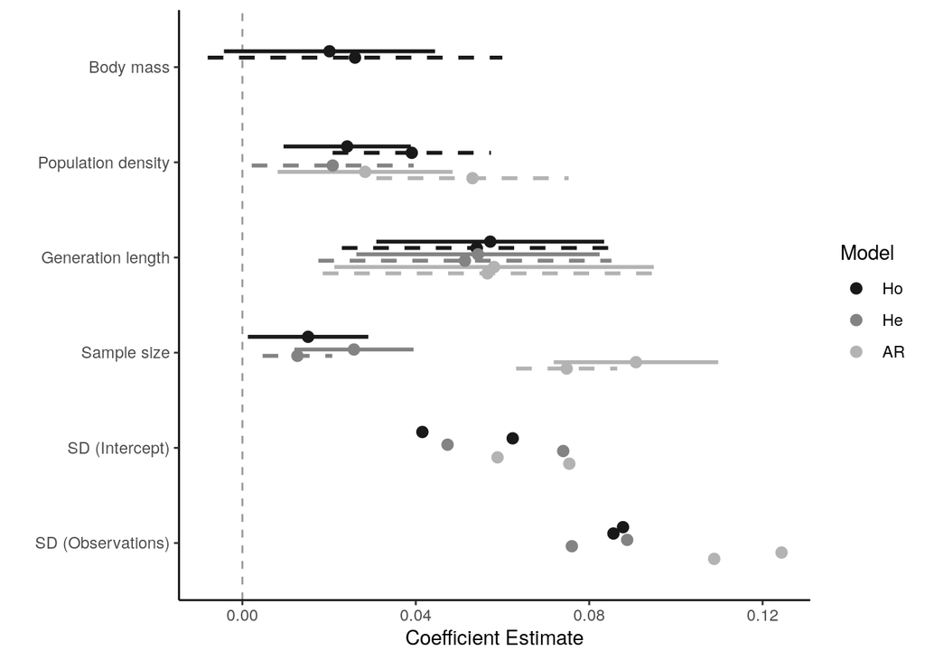

#### Model validation

##### Ho

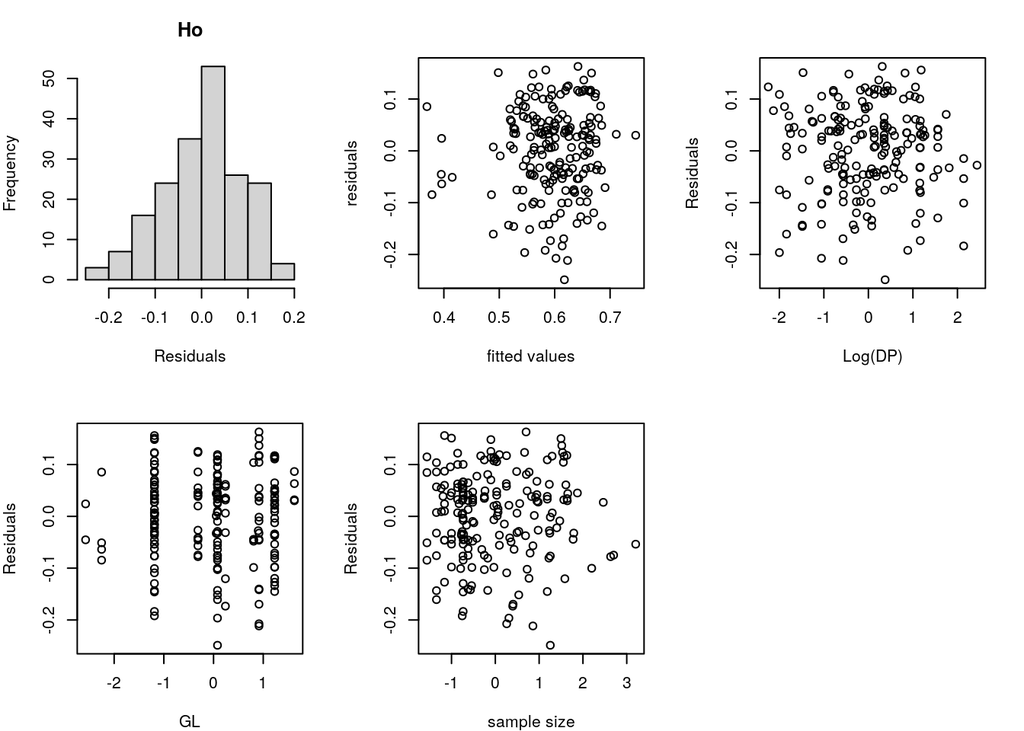

##### He

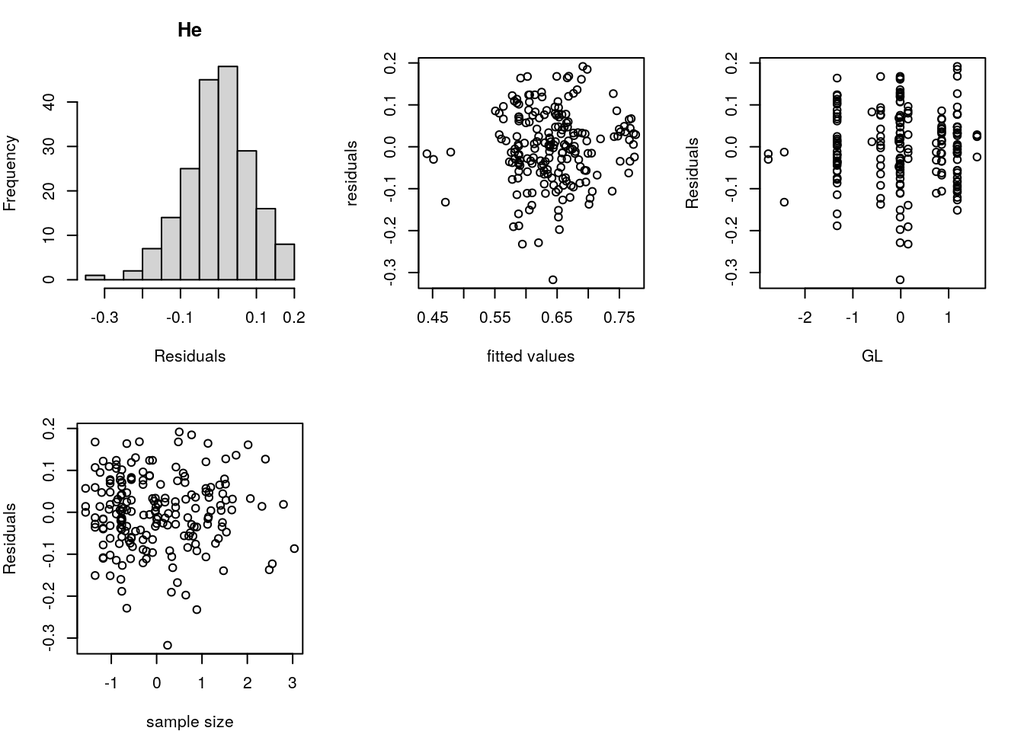

##### AR

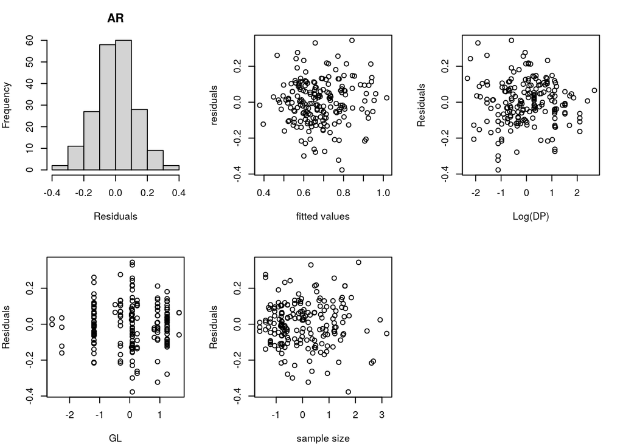

## PD in cluster vs country

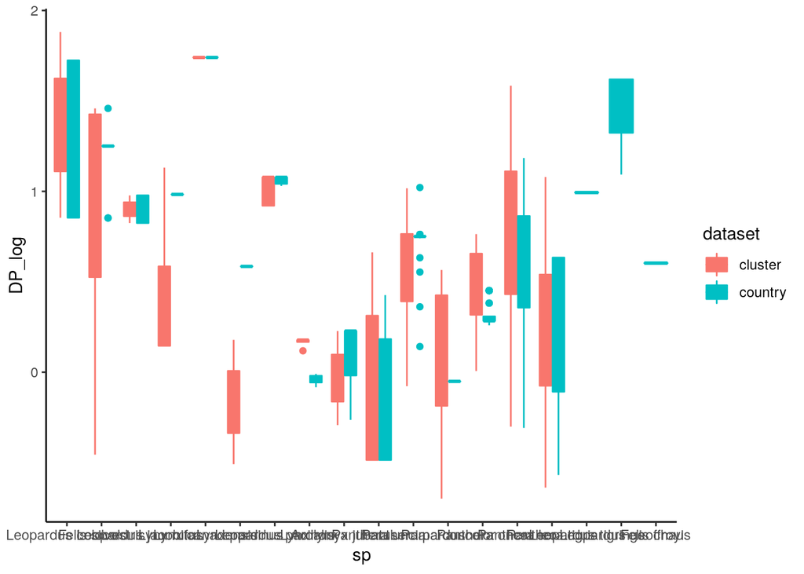

```r
tdy <- He.lmer@frame %>% mutate(dataset="cluster")

tdy.c <- He.c.lmer@frame %>% mutate(dataset="country")

tdy.com <- rbind(tdy, tdy.c)
tdy.com$dataset <- as.factor(tdy.com$dataset)

ggplot(data=tdy.com, aes(x=sp, y=DP_log, color=dataset, fill=dataset)) + geom_boxplot()
```

```r
table(tdy.com$sp, tdy.com$dataset)
```

```
##
##                       cluster country
##   Leopardus colocolo        2       6
##   Felis silvestris          4      10
##   Leopardus jacobita        2       4
##   Lynx rufus                4      59
##   Lynx canadensis           1      44
##   Lynx pardinus             2       2
##   Leopardus pardalis       11      10
##   Lynx lynx                 5       3
##   Acinonyx jubatus          2      11
##   Panthera uncia           13      11
##   Panthera pardus          18      20
##   Puma concolor            16      73
##   Panthera onca            42      44
##   Panthera leo             42      67
##   Panthera tigris          31      33
##   Leopardus tigrinus        0       1
##   Leopardus geoffroyi       0       4
##   Felis chaus               0       1
```

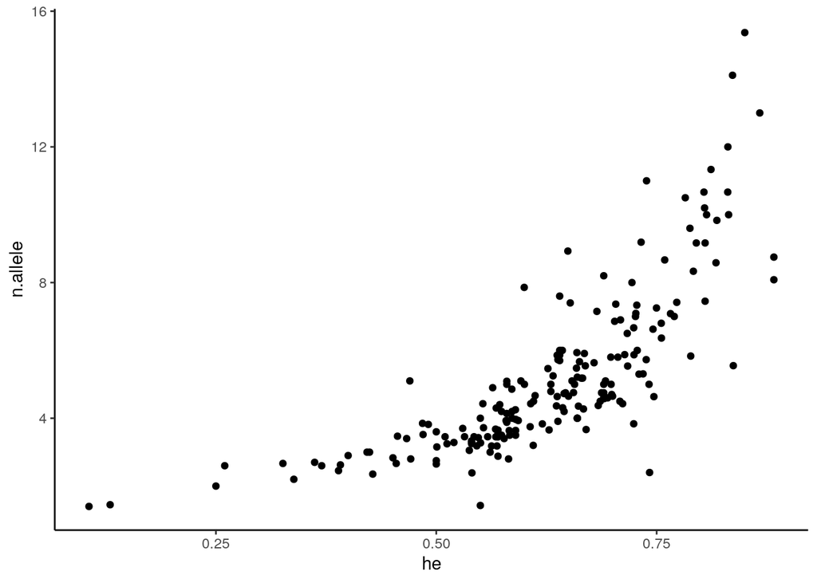

```r
ggplot(data=gen_clus, aes(x=he, y=n.allele)) + geom_point()
```

## fitted values by sp

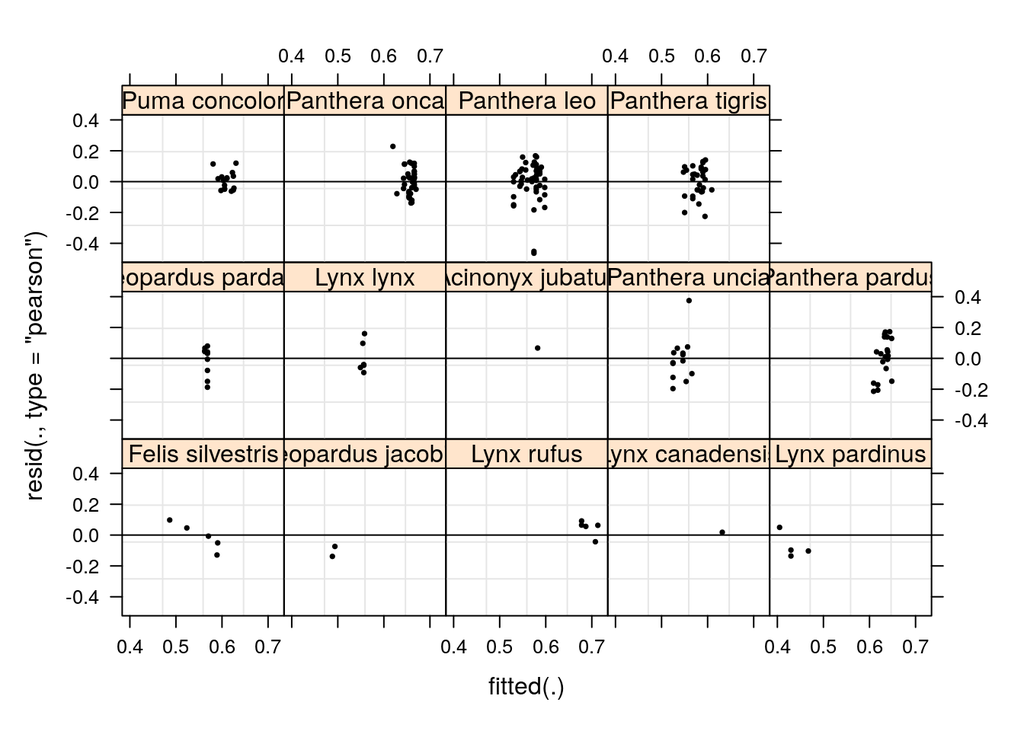

```r
plot(Ho.lmer.out, form = resid(., type = "pearson") ~ fitted(.) | sp, abline = 0,
     cex = .5, pch = 20, col = "black")
```

```r
library(nlme)
m4.lme = lme(ho ~ DP_log, random = ~1|sp, data = df_Ho, method = "ML")

m5.lme <- update(m4.lme, weights = varIdent(form = ~ 1 | sp), control = lmeControl(msMaxIter = 1000, msMaxEval = 1000))
# compare models
anova(m5.lme, m4.lme)
```

|  | call | Model | df | AIC | BIC | logLik | Test | L.Ratio | p-value |
| --- | --- | --- | --- | --- | --- | --- | --- | --- | --- |
| m5.lme | lme.formula(fixed = ho ~ DP_log, data = df_Ho, random = ~1 \| sp, weights = varIdent(form = ~1 \| sp), method = "ML", control = lmeControl(msMaxIter = 1000, msMaxEval = 1000)) | 1 | 17 | -299.3774 | -243.0529 | 166.6887 |  | NA | NA |
| m4.lme | lme.formula(fixed = ho ~ DP_log, data = df_Ho, random = ~1 \| sp, method = "ML") | 2 | 4 | -300.5211 | -287.2683 | 154.2606 | 1 vs 2 | 24.85628 | 0.02410785 |

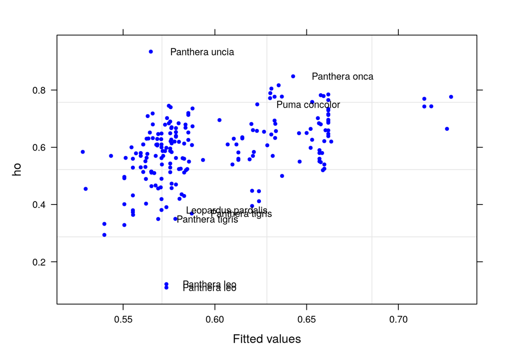

```r
# observed responses versus the within-group fitted values
plot(m5.lme, ho ~ fitted(.), id = 0.05, adj = -0.3,
     , cex = .8, pch = 20, col = "blue")
```

## Conduct leave-one-out cross validation I’m not entirely sure about this approach

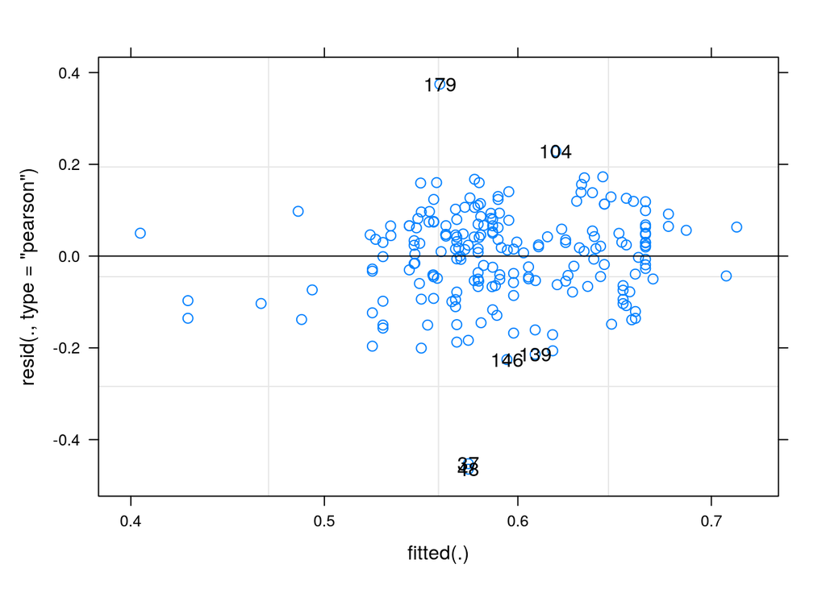

```r
plot(Ho.lmer.out, id = 0.05, idLabels = ~.obs)
```

```r
df_Ho[c(179,104,139,146,37,48),]
```

|  | sp | country | population.gen | population.den | cluster_center | sample.size | ho | he | n.allele | DP_max | DP_mean | BS | GenerationLength_d | ref.gen | ref.den | n.allele_log | sample.size_log | DP_log | BS_log | ho_out | he_out | ar_out | dp_out | label |
| --- | --- | --- | --- | --- | --- | --- | --- | --- | --- | --- | --- | --- | --- | --- | --- | --- | --- | --- | --- | --- | --- | --- | --- | --- |
| 195 | Panthera uncia | India | India | Hemis NP | 1_PA | 28.16667 | 0.9342289 | 0.7591616 | 8.666667 | 3.840676 | 3.0788072 | 40.25 | 2920.000 | janecka_range-wide_2017 | Jackson_Report_2005 | 0.9378521 | 1.449735 | 0.48838249 | 1.604766 | TRUE | FALSE | FALSE | FALSE | atop(italic(.uncia),India) |
| 108 | Panthera onca | Brazil | Cerrado | Emas NP | 25_NT | 12.00000 | 0.8480000 | 0.8050000 | 7.450000 | 0.290000 | 0.2300000 | 85.70 | 3581.681 | roques_effects_2016 | Finnegan_Animal Conservation_2020, Sollmann_Biological Conservation_2011 | 0.8721563 | 1.079181 | -0.63827216 | 1.932981 | FALSE | FALSE | FALSE | TRUE | atop(italic(.onca),Cerrado) |
| 150 | Panthera pardus | Russia | Basins of Ananievka and Nezhinka rivers | Borisovskoe Plateau Wildlife Refuge, Laoyeling Mountain, Laoyeling, Hunchun and Wangqing reserves, Land of the Leopard NP | 4_PA | 23.00000 | 0.3950000 | 0.4508333 | 2.833333 | 1.468323 | 0.8369033 | 41.00 | 3400.645 | rozhnov_individual_2013 | Miquelle_Report_2012, Qi_Biological Conservation_2015, Vitkalova_Conservation Letters_2018, Wang_Biological Conservation_2016 | 0.4522977 | 1.361728 | -0.07732473 | 1.612784 | FALSE | TRUE | FALSE | FALSE | atop(italic(.pardus),Basins~of~Ananievka~and~Nezhinka~rivers) |
| 157 | Panthera tigris | Bangladesh | Sunderbans | Sundarban Tiger Reserve | 18_IM | 53.00000 | 0.3687500 | 0.7137500 | 5.875000 | 5.200000 | 4.6400000 | 190.50 | 2920.000 | aziz_do_2018 | Das_Report_2012, Roy_Population Ecology_2015 | 0.7690079 | 1.724276 | 0.66651798 | 2.279895 | FALSE | FALSE | FALSE | FALSE | atop(italic(.tigris),Sunderbans) |
| 41 | Panthera leo | India | Gir forest NP | Gir Forest PA | 1_IM | 11.00000 | 0.1220000 | 0.1060000 | 1.400000 | 8.530000 | 8.5300000 | 145.10 | 2190.000 | antunes_the_2008 | Gogoi_PLOS ONE_2020 | 0.1461280 | 1.041393 | 0.93094903 | 2.161667 | TRUE | TRUE | TRUE | FALSE | atop(italic(.leo),Gir~forest~NP) |
| 52 | Panthera leo | India | Gir forest NP | Gir Forest PA | 1_IM | 10.00000 | 0.1100000 | 0.1300000 | 1.450000 | 8.530000 | 8.5300000 | 145.10 | 2190.000 | bertola_autosomal_2015 | Gogoi_PLOS ONE_2020 | 0.1613680 | 1.000000 | 0.93094903 | 2.161667 | TRUE | TRUE | TRUE | FALSE | atop(italic(.leo),Gir~forest~NP) |

## Manually

### Using all data (including outliers)

The list’s name indicate the species data that were left out

*Ho*

```r
sp_i <- unique(df_Ho$sp)
res_sp <- list()

for (i in sp_i) {
  res_sp[[i]] <- update(Ho.lmer.out, data=df_Ho[-which(df_Ho$sp == i),])
}

lapply(res_sp, summary)
```

```
## $`Acinonyx jubatus`
## Linear mixed model fit by maximum likelihood . t-tests use Satterthwaite's
##   method [lmerModLmerTest]
## Formula: ho ~ DP_log + (1 | sp)
##    Data: df_Ho[-which(df_Ho$sp == i), ]
##
##      AIC      BIC   logLik deviance df.resid
##   -298.9   -285.7    153.4   -306.9      198
##
## Scaled residuals:
##     Min      1Q  Median      3Q     Max
## -4.3502 -0.5296  0.1589  0.6129  3.5082
##
## Random effects:
##  Groups   Name        Variance Std.Dev.
##  sp       (Intercept) 0.005667 0.07528
##  Residual             0.011399 0.10677
## Number of obs: 202, groups:  sp, 13
##
## Fixed effects:
##              Estimate Std. Error        df t value Pr(>|t|)
## (Intercept)   0.55679    0.02492  10.37715  22.347 4.09e-10 ***
## DP_log        0.03699    0.01609 201.75521   2.299   0.0226 *
## ---
## Signif. codes:  0 '***' 0.001 '**' 0.01 '*' 0.05 '.' 0.1 ' ' 1
##
## Correlation of Fixed Effects:
##        (Intr)
## DP_log -0.303
##
## $`Felis silvestris`
## Linear mixed model fit by maximum likelihood . t-tests use Satterthwaite's
##   method [lmerModLmerTest]
## Formula: ho ~ DP_log + (1 | sp)
##    Data: df_Ho[-which(df_Ho$sp == i), ]
##
##      AIC      BIC   logLik deviance df.resid
##   -291.8   -278.6    149.9   -299.8      194
##
## Scaled residuals:
```

[output cut: 364 more lines]

```
##  Groups   Name        Variance Std.Dev.
##  sp       (Intercept) 0.005808 0.07621
##  Residual             0.012070 0.10986
## Number of obs: 187, groups:  sp, 13
##
## Fixed effects:
##              Estimate Std. Error        df t value Pr(>|t|)
## (Intercept)   0.55521    0.02609  10.57004  21.280 5.09e-10 ***
## DP_log        0.03741    0.01696 186.81654   2.206   0.0286 *
## ---
## Signif. codes:  0 '***' 0.001 '**' 0.01 '*' 0.05 '.' 0.1 ' ' 1
##
## Correlation of Fixed Effects:
##        (Intr)
## DP_log -0.309
```

*He*

```r
sp_i <- unique(df_He$sp)
res_sp <- list()

for (i in sp_i) {
  res_sp[[i]] <- update(He.lmer.out, data=df_He[-which(df_He$sp == i),])
}
lapply(res_sp, summary)
```

```
## $`Acinonyx jubatus`
## Linear mixed model fit by maximum likelihood . t-tests use Satterthwaite's
##   method [lmerModLmerTest]
## Formula: he ~ DP_log + (1 | sp)
##    Data: df_He[-which(df_He$sp == i), ]
##
##      AIC      BIC   logLik deviance df.resid
##   -279.6   -266.3    143.8   -287.6      203
##
## Scaled residuals:
##     Min      1Q  Median      3Q     Max
## -4.1542 -0.4702  0.0181  0.6539  1.9711
##
## Random effects:
##  Groups   Name        Variance Std.Dev.
##  sp       (Intercept) 0.003919 0.06261
##  Residual             0.013311 0.11537
## Number of obs: 207, groups:  sp, 14
##
## Fixed effects:
##              Estimate Std. Error        df t value Pr(>|t|)
## (Intercept)   0.61404    0.02224  11.05320  27.605 1.51e-11 ***
## DP_log        0.01964    0.01735 199.54802   1.132    0.259
## ---
## Signif. codes:  0 '***' 0.001 '**' 0.01 '*' 0.05 '.' 0.1 ' ' 1
##
## Correlation of Fixed Effects:
##        (Intr)
## DP_log -0.379
##
## $`Felis silvestris`
## Linear mixed model fit by maximum likelihood . t-tests use Satterthwaite's
##   method [lmerModLmerTest]
## Formula: he ~ DP_log + (1 | sp)
##    Data: df_He[-which(df_He$sp == i), ]
##
##      AIC      BIC   logLik deviance df.resid
##   -273.9   -260.6    140.9   -281.9      199
##
## Scaled residuals:
```

[output cut: 394 more lines]

```
##  Groups   Name        Variance Std.Dev.
##  sp       (Intercept) 0.00408  0.06387
##  Residual             0.01393  0.11801
## Number of obs: 193, groups:  sp, 14
##
## Fixed effects:
##              Estimate Std. Error        df t value Pr(>|t|)
## (Intercept)   0.60954    0.02343  12.34990  26.014 3.68e-12 ***
## DP_log        0.02320    0.01821 188.19952   1.275    0.204
## ---
## Signif. codes:  0 '***' 0.001 '**' 0.01 '*' 0.05 '.' 0.1 ' ' 1
##
## Correlation of Fixed Effects:
##        (Intr)
## DP_log -0.392
```

*Allelic richness*

```r
sp_i <- unique(df_mna$sp)
res_sp <- list()

for (i in sp_i) {
  res_sp[[i]] <- update(mna.lmer.out, data=df_mna[-which(df_mna$sp == i),])
}
lapply(res_sp, summary)
```

```
## $`Acinonyx jubatus`
## Linear mixed model fit by maximum likelihood . t-tests use Satterthwaite's
##   method [lmerModLmerTest]
## Formula: n.allele_log ~ DP_log + (1 | sp)
##    Data: df_mna[-which(df_mna$sp == i), ]
##
##      AIC      BIC   logLik deviance df.resid
##   -130.2   -116.9     69.1   -138.2      202
##
## Scaled residuals:
##     Min      1Q  Median      3Q     Max
## -3.0969 -0.6223 -0.0192  0.5895  3.0689
##
## Random effects:
##  Groups   Name        Variance Std.Dev.
##  sp       (Intercept) 0.01121  0.1059
##  Residual             0.02684  0.1638
## Number of obs: 206, groups:  sp, 14
##
## Fixed effects:
##              Estimate Std. Error        df t value Pr(>|t|)
## (Intercept)   0.64213    0.03560  13.59878   18.04 6.91e-11 ***
## DP_log        0.06408    0.02436 205.97905    2.63  0.00918 **
## ---
## Signif. codes:  0 '***' 0.001 '**' 0.01 '*' 0.05 '.' 0.1 ' ' 1
##
## Correlation of Fixed Effects:
##        (Intr)
## DP_log -0.363
##
## $`Felis silvestris`
## Linear mixed model fit by maximum likelihood . t-tests use Satterthwaite's
##   method [lmerModLmerTest]
## Formula: n.allele_log ~ DP_log + (1 | sp)
##    Data: df_mna[-which(df_mna$sp == i), ]
##
##      AIC      BIC   logLik deviance df.resid
##   -131.5   -118.3     69.8   -139.5      198
##
## Scaled residuals:
```

[output cut: 394 more lines]

```
##  Groups   Name        Variance Std.Dev.
##  sp       (Intercept) 0.01135  0.1065
##  Residual             0.02822  0.1680
## Number of obs: 192, groups:  sp, 14
##
## Fixed effects:
##              Estimate Std. Error        df t value Pr(>|t|)
## (Intercept)   0.63726    0.03692  14.64768  17.259 3.86e-11 ***
## DP_log        0.06454    0.02558 191.99774   2.523   0.0125 *
## ---
## Signif. codes:  0 '***' 0.001 '**' 0.01 '*' 0.05 '.' 0.1 ' ' 1
##
## Correlation of Fixed Effects:
##        (Intr)
## DP_log -0.374
```

### Country dataset

*Ho*

```r
sp_i <- unique(df_Ho.c$sp)
res_sp <- list()

for (i in sp_i) {
  res_sp[[i]] <- update(Ho.c.lmer.out, data=df_Ho.c[-which(df_Ho.c$sp == i),])
}

lapply(res_sp, summary)
```

```
## $`Acinonyx jubatus`
## Linear mixed model fit by maximum likelihood . t-tests use Satterthwaite's
##   method [lmerModLmerTest]
## Formula: ho ~ DP_log + (1 | sp)
##    Data: df_Ho.c[-which(df_Ho.c$sp == i), ]
##
##      AIC      BIC   logLik deviance df.resid
##   -672.6   -656.6    340.3   -680.6      396
##
## Scaled residuals:
##     Min      1Q  Median      3Q     Max
## -4.6685 -0.5627  0.1170  0.6025  4.0539
##
## Random effects:
##  Groups   Name        Variance Std.Dev.
##  sp       (Intercept) 0.006584 0.08114
##  Residual             0.009761 0.09880
## Number of obs: 400, groups:  sp, 16
##
## Fixed effects:
##              Estimate Std. Error        df t value Pr(>|t|)
## (Intercept)   0.55215    0.02455  17.80851  22.492 1.59e-14 ***
## DP_log        0.03491    0.01537 326.97201   2.271   0.0238 *
## ---
## Signif. codes:  0 '***' 0.001 '**' 0.01 '*' 0.05 '.' 0.1 ' ' 1
##
## Correlation of Fixed Effects:
##        (Intr)
## DP_log -0.401
##
## $`Felis chaus`
## Linear mixed model fit by maximum likelihood . t-tests use Satterthwaite's
##   method [lmerModLmerTest]
## Formula: ho ~ DP_log + (1 | sp)
##    Data: df_Ho.c[-which(df_Ho.c$sp == i), ]
##
##      AIC      BIC   logLik deviance df.resid
##   -678.9   -662.9    343.5   -686.9      400
##
## Scaled residuals:
```

[output cut: 454 more lines]

```
##  Groups   Name        Variance Std.Dev.
##  sp       (Intercept) 0.006795 0.08243
##  Residual             0.010324 0.10161
## Number of obs: 300, groups:  sp, 16
##
## Fixed effects:
##              Estimate Std. Error        df t value Pr(>|t|)
## (Intercept)   0.56056    0.02537  19.01232   22.09  5.1e-15 ***
## DP_log        0.02550    0.01624 263.42277    1.57    0.118
## ---
## Signif. codes:  0 '***' 0.001 '**' 0.01 '*' 0.05 '.' 0.1 ' ' 1
##
## Correlation of Fixed Effects:
##        (Intr)
## DP_log -0.415
```

*He*

```r
sp_i <- unique(df_He.c$sp)
res_sp <- list()

for (i in sp_i) {
  res_sp[[i]] <- update(He.c.lmer.out, data=df_He.c[-which(df_He.c$sp == i),])
}
lapply(res_sp, summary)
```

```
## $`Acinonyx jubatus`
## Linear mixed model fit by maximum likelihood . t-tests use Satterthwaite's
##   method [lmerModLmerTest]
## Formula: he ~ DP_log + (1 | sp)
##    Data: df_He.c[-which(df_He.c$sp == i), ]
##
##      AIC      BIC   logLik deviance df.resid
##   -649.2   -632.7    328.6   -657.2      445
##
## Scaled residuals:
##     Min      1Q  Median      3Q     Max
## -4.3655 -0.3223  0.1385  0.5278  2.5027
##
## Random effects:
##  Groups   Name        Variance Std.Dev.
##  sp       (Intercept) 0.006184 0.07864
##  Residual             0.012544 0.11200
## Number of obs: 449, groups:  sp, 17
##
## Fixed effects:
##              Estimate Std. Error        df t value Pr(>|t|)
## (Intercept)   0.59938    0.02453  17.46663  24.433 5.97e-15 ***
## DP_log        0.04157    0.01649 272.81630   2.521   0.0123 *
## ---
## Signif. codes:  0 '***' 0.001 '**' 0.01 '*' 0.05 '.' 0.1 ' ' 1
##
## Correlation of Fixed Effects:
##        (Intr)
## DP_log -0.464
##
## $`Felis chaus`
## Linear mixed model fit by maximum likelihood . t-tests use Satterthwaite's
##   method [lmerModLmerTest]
## Formula: he ~ DP_log + (1 | sp)
##    Data: df_He.c[-which(df_He.c$sp == i), ]
##
##      AIC      BIC   logLik deviance df.resid
##   -673.5   -657.0    340.8   -681.5      456
##
## Scaled residuals:
```

[output cut: 484 more lines]

```
##  Groups   Name        Variance Std.Dev.
##  sp       (Intercept) 0.00699  0.08361
##  Residual             0.01054  0.10269
## Number of obs: 354, groups:  sp, 17
##
## Fixed effects:
##              Estimate Std. Error        df t value Pr(>|t|)
## (Intercept)   0.61444    0.02525  18.20959  24.338 2.42e-15 ***
## DP_log        0.02507    0.01580 292.13623   1.586    0.114
## ---
## Signif. codes:  0 '***' 0.001 '**' 0.01 '*' 0.05 '.' 0.1 ' ' 1
##
## Correlation of Fixed Effects:
##        (Intr)
## DP_log -0.442
```

*Allelic richness*

```r
sp_i <- unique(df_mna.c$sp)
res_sp <- list()

for (i in sp_i) {
  res_sp[[i]] <- update(mna.c.lmer.out, data=df_mna.c[-which(df_mna.c$sp == i),])
}
lapply(res_sp, summary)
```

```
## $`Acinonyx jubatus`
## Linear mixed model fit by maximum likelihood . t-tests use Satterthwaite's
##   method [lmerModLmerTest]
## Formula: n.allele_log ~ DP_log + (1 | sp)
##    Data: df_mna.c[-which(df_mna.c$sp == i), ]
##
##      AIC      BIC   logLik deviance df.resid
##   -321.9   -305.7    165.0   -329.9      422
##
## Scaled residuals:
##     Min      1Q  Median      3Q     Max
## -3.3744 -0.4935  0.0580  0.5967  3.0196
##
## Random effects:
##  Groups   Name        Variance Std.Dev.
##  sp       (Intercept) 0.01104  0.1051
##  Residual             0.02504  0.1582
## Number of obs: 426, groups:  sp, 16
##
## Fixed effects:
##              Estimate Std. Error        df t value Pr(>|t|)
## (Intercept)   0.62381    0.03384  19.28764  18.433 1.04e-13 ***
## DP_log        0.08938    0.02360 270.54903   3.787 0.000188 ***
## ---
## Signif. codes:  0 '***' 0.001 '**' 0.01 '*' 0.05 '.' 0.1 ' ' 1
##
## Correlation of Fixed Effects:
##        (Intr)
## DP_log -0.484
##
## $`Felis silvestris`
## Linear mixed model fit by maximum likelihood . t-tests use Satterthwaite's
##   method [lmerModLmerTest]
## Formula: n.allele_log ~ DP_log + (1 | sp)
##    Data: df_mna.c[-which(df_mna.c$sp == i), ]
##
##      AIC      BIC   logLik deviance df.resid
##   -339.8   -323.6    173.9   -347.8      422
##
## Scaled residuals:
```

[output cut: 454 more lines]

```
##  Groups   Name        Variance Std.Dev.
##  sp       (Intercept) 0.01133  0.1064
##  Residual             0.02361  0.1537
## Number of obs: 321, groups:  sp, 16
##
## Fixed effects:
##              Estimate Std. Error        df t value Pr(>|t|)
## (Intercept)   0.64054    0.03436  20.33901  18.642 2.93e-14 ***
## DP_log        0.07100    0.02370 250.76448   2.996  0.00301 **
## ---
## Signif. codes:  0 '***' 0.001 '**' 0.01 '*' 0.05 '.' 0.1 ' ' 1
##
## Correlation of Fixed Effects:
##        (Intr)
## DP_log -0.490
```